# Much Ado About Nothing

Rhys Maredudd Davies

26 October, 2023

# Handling missing data in research.

Throughout this workshop, we will be using data sets built into R packages in order to examine missing data. This is so that we can focus on the functions and the theory, rather than worrying about loading/uploading data sets. Some of the statistical methods used today might be unfamiliar to you, and may be intimidating. However, understanding these is not essential for today - so please see them as a tool. If we have time at the end of the session, we can attempt to explain.

All that aside, let’s focus on what we are going to work through today. Our main learning aims are:

- To describe our missing data.
- To summarise our missing data (around variables and around cases)
- To explore our missing data
- To categorise our missing data as MCAR, MAR, or MNAR.
- To see the impact of different missing data management methods across MCAR, MAR, and MNAR.

## Missing data descriptives

So first off, lets examine our data set for today using our workhorse of data exploring - `summary()`. Our first dataset is `airquality`, which contains data on daily air quality measurements in New York, May to September 1973.

```r
#?airquality
airquality %>% summary()
```

```
##      Ozone           Solar.R           Wind             Temp
##  Min.   :  1.00   Min.   :  7.0   Min.   : 1.700   Min.   :56.00
##  1st Qu.: 18.00   1st Qu.:115.8   1st Qu.: 7.400   1st Qu.:72.00
##  Median : 31.50   Median :205.0   Median : 9.700   Median :79.00
##  Mean   : 42.13   Mean   :185.9   Mean   : 9.958   Mean   :77.88
##  3rd Qu.: 63.25   3rd Qu.:258.8   3rd Qu.:11.500   3rd Qu.:85.00
##  Max.   :168.00   Max.   :334.0   Max.   :20.700   Max.   :97.00
##  NA's   :37       NA's   :7
##      Month            Day
##  Min.   :5.000   Min.   : 1.0
##  1st Qu.:6.000   1st Qu.: 8.0
##  Median :7.000   Median :16.0
##  Mean   :6.993   Mean   :15.8
##  3rd Qu.:8.000   3rd Qu.:23.0
##  Max.   :9.000   Max.   :31.0
##
```

```r
# Also, we need to transform our Monnth and Day to a factor to allow for more accurate analysis.
airquality_f <- airquality %>% mutate(Month = as.factor(Month),
                                      Day = as.factor(Day))

airquality_f %>% summary()
```

```
##      Ozone           Solar.R           Wind             Temp       Month
##  Min.   :  1.00   Min.   :  7.0   Min.   : 1.700   Min.   :56.00   5:31
##  1st Qu.: 18.00   1st Qu.:115.8   1st Qu.: 7.400   1st Qu.:72.00   6:30
##  Median : 31.50   Median :205.0   Median : 9.700   Median :79.00   7:31
##  Mean   : 42.13   Mean   :185.9   Mean   : 9.958   Mean   :77.88   8:31
##  3rd Qu.: 63.25   3rd Qu.:258.8   3rd Qu.:11.500   3rd Qu.:85.00   9:30
##  Max.   :168.00   Max.   :334.0   Max.   :20.700   Max.   :97.00
##  NA's   :37       NA's   :7
##       Day
##  1      :  5
##  2      :  5
##  3      :  5
##  4      :  5
##  5      :  5
##  6      :  5
##  (Other):123
```

So we can instantly see that we have 37 NA’s in `Ozone`, and 7 NA’s in `Solar.R`. We can also see that we have a sample size of 153 observations across our 6 variables.

Now we can see what happens to our sample size if we instinctivley remove our NA’s:

```r
NA_removed_airquality <- airquality_f %>% na.omit()
summary(NA_removed_airquality)
```

```
##      Ozone          Solar.R           Wind            Temp       Month
##  Min.   :  1.0   Min.   :  7.0   Min.   : 2.30   Min.   :57.00   5:24
##  1st Qu.: 18.0   1st Qu.:113.5   1st Qu.: 7.40   1st Qu.:71.00   6: 9
##  Median : 31.0   Median :207.0   Median : 9.70   Median :79.00   7:26
##  Mean   : 42.1   Mean   :184.8   Mean   : 9.94   Mean   :77.79   8:23
##  3rd Qu.: 62.0   3rd Qu.:255.5   3rd Qu.:11.50   3rd Qu.:84.50   9:29
##  Max.   :168.0   Max.   :334.0   Max.   :20.70   Max.   :97.00
##
##       Day
##  7      : 5
##  9      : 5
##  13     : 5
##  16     : 5
##  17     : 5
##  18     : 5
##  (Other):81
```

So instead, let’s have a look at summaries specific to our missing data:

```r
## Summaries for missing data across data
n_miss(airquality_f) # provides total number of missing datum's across data
```

```
## [1] 44
```

```r
n_complete(airquality_f) # Provides total number of complete datum's across data
```

```
## [1] 874
```

```r
pct_miss(airquality_f) # Provides the percentage of missing data - very useful for reporting.
```

```
## [1] 4.793028
```

```r
pct_complete(airquality_f) # Provides the percentage of complete data.
```

```
## [1] 95.20697
```

```r
## Summaries of missing data across variables and cases
miss_var_summary(airquality_f) # A summary of n missing and % missing across each variables
```

```
## # A tibble: 6 × 3
##   variable n_miss pct_miss
##   <chr>     <int>    <dbl>
## 1 Ozone        37    24.2
## 2 Solar.R       7     4.58
## 3 Wind          0     0
## 4 Temp          0     0
## 5 Month         0     0
## 6 Day           0     0
```

```r
miss_var_table(airquality_f) # A generalised summary of n missing per variable, with associated %.
```

```
## # A tibble: 3 × 3
##   n_miss_in_var n_vars pct_vars
##           <int>  <int>    <dbl>
## 1             0      4     66.7
## 2             7      1     16.7
## 3            37      1     16.7
```

```r
miss_case_summary(airquality_f) # A case by case summary of n missing and % missing. Very useful for survey data if you need to remove participant who barely attempted completion.
```

```
## # A tibble: 153 × 3
##     case n_miss pct_miss
##    <int>  <int>    <dbl>
##  1     5      2     33.3
##  2    27      2     33.3
##  3     6      1     16.7
##  4    10      1     16.7
##  5    11      1     16.7
##  6    25      1     16.7
##  7    26      1     16.7
##  8    32      1     16.7
##  9    33      1     16.7
## 10    34      1     16.7
## # ℹ 143 more rows
```

```r
miss_case_table(airquality_f) # A generalised summary of n missing per case, with associated %
```

```
## # A tibble: 3 × 3
##   n_miss_in_case n_cases pct_cases
##            <int>   <int>     <dbl>
## 1              0     111     72.5
## 2              1      40     26.1
## 3              2       2      1.31
```

Summaries and numbers are nice, but they aren’t always best for full comprehension of understanding what’s missing in our lives/data. But thankfully we can visualise this aspect.

## Missing data visualisation

### Visually Exploring Data Summaries

Now it’s time to move onto visualising our missing data, so that we can estimate an understanding of what may be going on. Now visualising something that doesn’t exist sounds like a pretty philosophical concept to get our heads around. But thankfully, packages such as `naniar` makes it a lot easier for us to grasp.

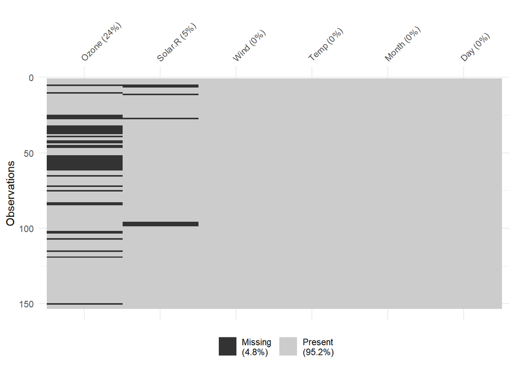

```r
## Mising data summaries

vis_miss(airquality_f)
```

This first plot provides a specific visualiation of the amount of missing data. In black we see the location of missing values. In the legend we have information on the overall percentage of missing values. However, this plot does make it a little tricky to see intersections and combinations of missingness.

Thankfully there is a tool in the form of `gg_miss_upset()` to save the day.

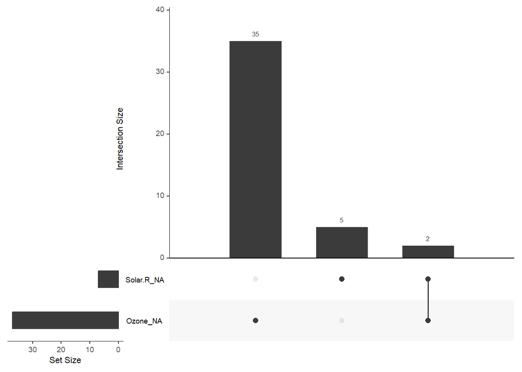

```r
gg_miss_upset(airquality_f)
```

From the upset plot, we see very clearly that: * Only Ozone and Solar.R have missing values * Ozone has the most missing values * There are 2 cases where both Solar.R and Ozone have missing values together,

But perhaps maybe we want a clear comparison of missingness across our data. For this we have `gg_miss_var()`. This function is particularly useful as it allows us to group our missing data by another variable by using the `facet` argument.

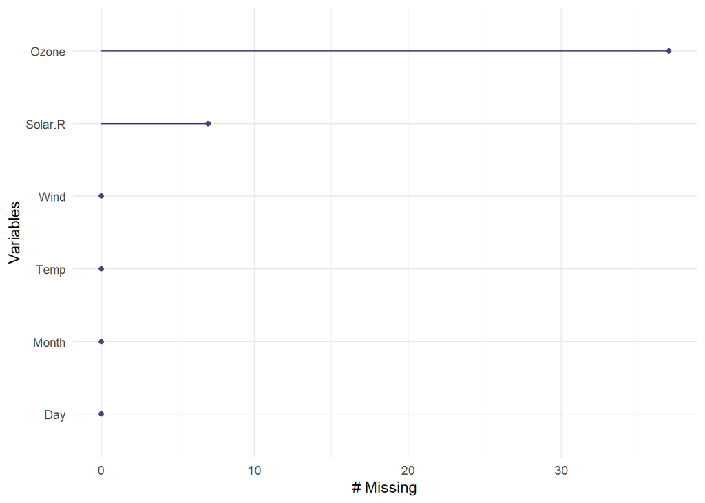

```r
gg_miss_var(airquality_f) # No grouping - across the enitre data.
```

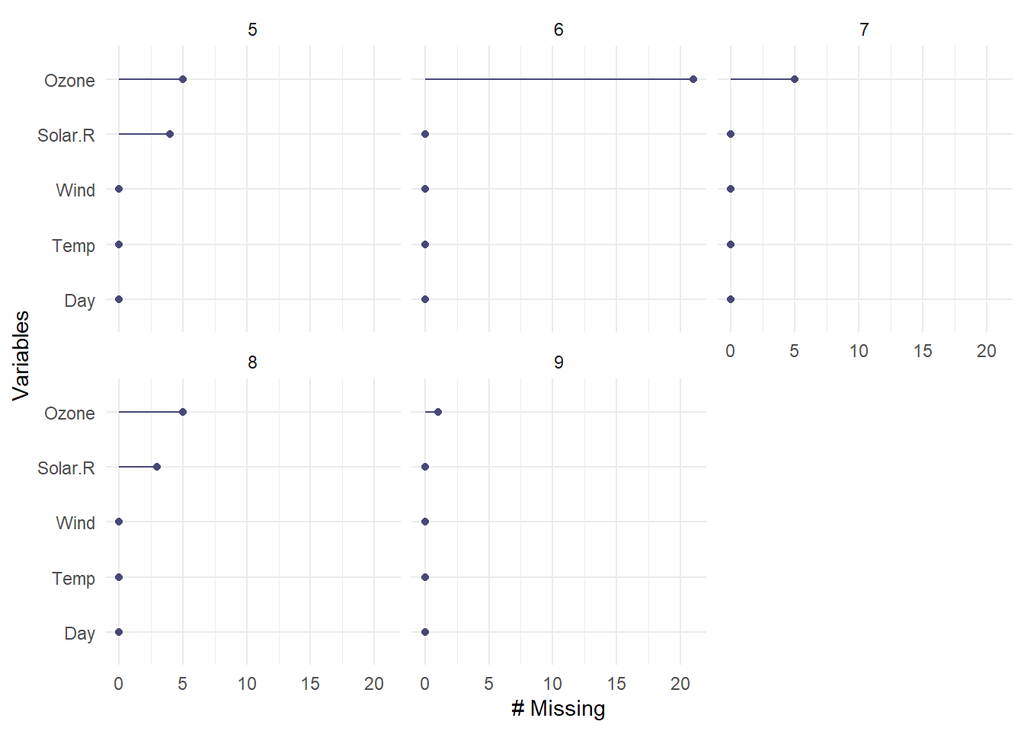

```r
gg_miss_var(airquality_f,
            facet = Month) # Grouped by Month (labelled numerically here - so 6 (June) has highest missing data)
```

From the faceted plot, we can start to infer that the Month variable might explain the missing data.

We can also visualise summaries of missing cases. To do so, we use the `gg_miss_case()` function. Much like the plots above, we can also group of visualisation here using the `facet` argument.

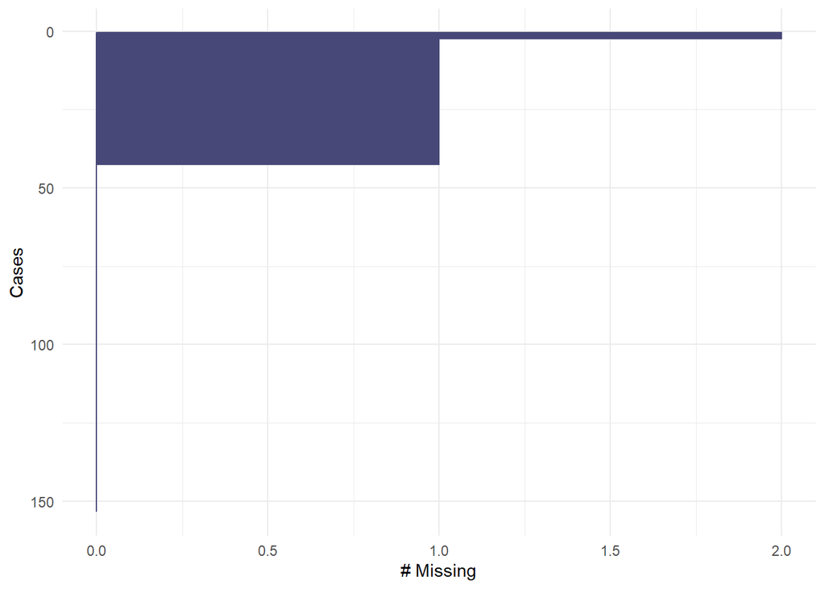

```r
gg_miss_case(airquality_f) # Total cases missing
```

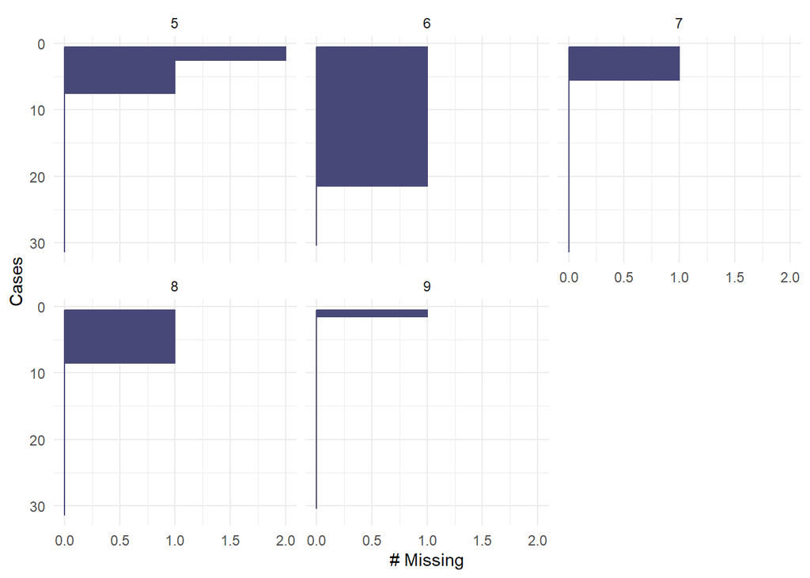

```r
gg_miss_case(airquality_f,
             facet = Month) # Cases missing, grouped by month.
```

## Exploring Missing Data Mechanisms

### Determening MCAR

Our first is to determine if our missing data is MCAR - missing at random. If it is, we can in theory remove our missing data without biasing (although other options are prefered). However, if it is not MCAR, then we need to determine if the data is MAR or MNAR.

For this will use the Little (1988) MCAR test. The Null hypothesis for this test is that the missing data is MCAR - that is, if p is greater than .05, we can infer that there is no pattern to our missingness, and that it is completely at random. However, if p is less than .05, we need further analysis to determine if missing data is MAR or MNAR. The test statistic here is chi-squared value.

*note on mcar_test : There are some complications/limitations here. Under the null hypothesis the data are actually MCAR or MNAR, while a statistically significant result indicates that missing data are MAR or MNAR, i.e., MNAR cannot be ruled out regardless of the result of the test.

```r
mcar_test(airquality_f)
```

```
## # A tibble: 1 × 4
##   statistic    df p.value missing.patterns
##       <dbl> <dbl>   <dbl>            <int>
## 1      35.1    14 0.00142                4
```

```r
# We can also use "shadow data" to determine missing data categories. This creates a new binary column, which differentiates between Na and not Na.

# Step 1 - create shadow (binary NA vs !NA)
shadow_airquality <- bind_shadow(airquality_f) #%>% mutate(Month = as.factor(Month))
head(shadow_airquality)
```

```
## # A tibble: 6 × 12
##   Ozone Solar.R  Wind  Temp Month Day   Ozone_NA Solar.R_NA Wind_NA Temp_NA
##   <int>   <int> <dbl> <int> <fct> <fct> <fct>    <fct>      <fct>   <fct>
## 1    41     190   7.4    67 5     1     !NA      !NA        !NA     !NA
## 2    36     118   8      72 5     2     !NA      !NA        !NA     !NA
## 3    12     149  12.6    74 5     3     !NA      !NA        !NA     !NA
## 4    18     313  11.5    62 5     4     !NA      !NA        !NA     !NA
## 5    NA      NA  14.3    56 5     5     NA       NA         !NA     !NA
## 6    28      NA  14.9    66 5     6     !NA      NA         !NA     !NA
## # ℹ 2 more variables: Month_NA <fct>, Day_NA <fct>
```

```r
summary(shadow_airquality)
```

```
##      Ozone           Solar.R           Wind             Temp       Month
##  Min.   :  1.00   Min.   :  7.0   Min.   : 1.700   Min.   :56.00   5:31
##  1st Qu.: 18.00   1st Qu.:115.8   1st Qu.: 7.400   1st Qu.:72.00   6:30
##  Median : 31.50   Median :205.0   Median : 9.700   Median :79.00   7:31
##  Mean   : 42.13   Mean   :185.9   Mean   : 9.958   Mean   :77.88   8:31
##  3rd Qu.: 63.25   3rd Qu.:258.8   3rd Qu.:11.500   3rd Qu.:85.00   9:30
##  Max.   :168.00   Max.   :334.0   Max.   :20.700   Max.   :97.00
##  NA's   :37       NA's   :7
##       Day      Ozone_NA  Solar.R_NA Wind_NA   Temp_NA   Month_NA  Day_NA
##  1      :  5   !NA:116   !NA:146    !NA:153   !NA:153   !NA:153   !NA:153
##  2      :  5   NA : 37   NA :  7    NA :  0   NA :  0   NA :  0   NA :  0
##  3      :  5
##  4      :  5
##  5      :  5
##  6      :  5
##  (Other):123
```

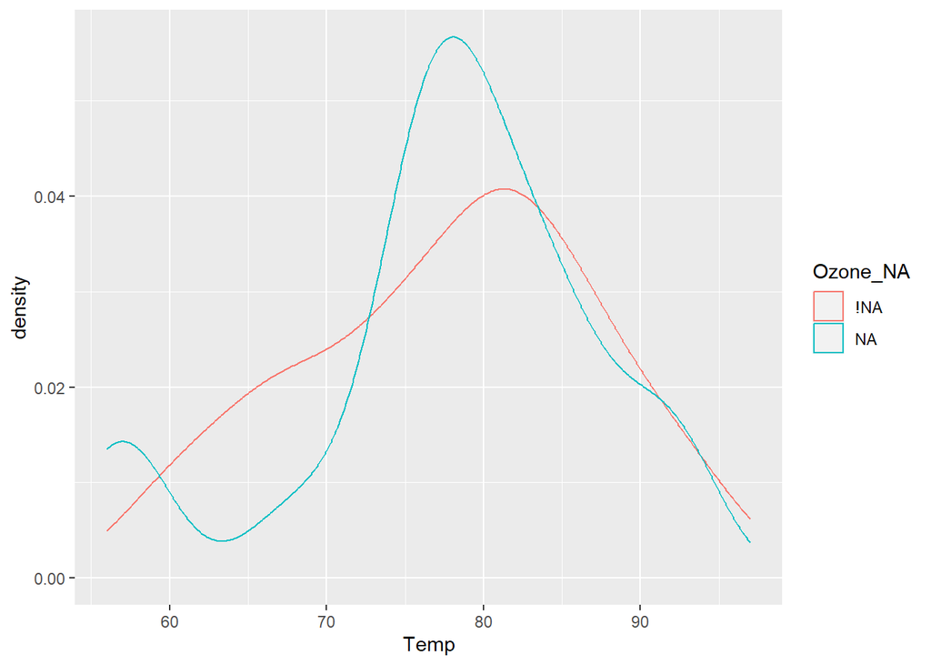

```r
# Step 2 - distribution plots to visualise

ggplot(shadow_airquality,
       aes(x = Temp,
           colour = Ozone_NA)) +
  geom_density()
```

Well… it looks like our p value is considerably less than .05 *(p = .001)*, and that our test statistic is high. The only thing we can conclude from here is that our missing data is *not* MCAR. If we were to delete our NA under this scenario, we would *bias* our analysis.

As such it’s time to explore/and theoretically determine potential causes for our missing data to determine if we have *MAR* or *MNAR*. If we can determine *MAR* we can apply the appropriate imputation strategy to analyse with greater confidence.

### MAR vs MNAR data exploration

At this point, having a theoretical knowledge of your data will be priceless. If you can already infer potential causes for why data might be missing, you will have a much stronger case to justify your decisions, and you will be able to infer patterns much quicker. A case to remember at this stage: “correlation is not causation”.

However, for now, lets visually explore our missing cases/

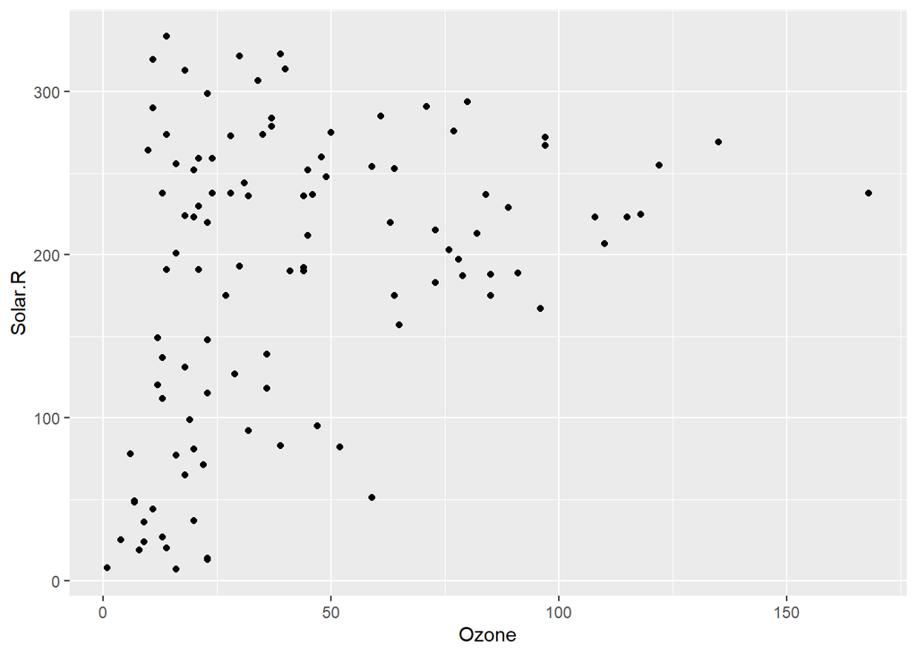

```r
# Plot with missing data excluded
ggplot(data = airquality_f,
       aes(x = Ozone,
           y = Solar.R)) +
  geom_point()
```

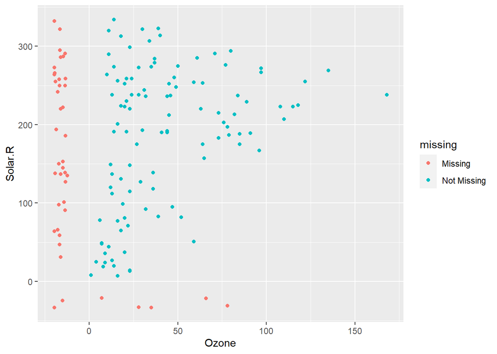

```r
# Plot with missing data visualised - Interesting, but is there a pattern?
ggplot(data = airquality_f,
       aes(x = Ozone,
           y = Solar.R)) +
  geom_miss_point()
```

So how does this work? What are we looking at? `geom_miss_point()` has shifts the missing values , so that they are 10% below the minimum value. The missing values are a different colour so that we can identify missingness. As it is a ggplot2 geom, we can use other ggplot features like faceting and `geom_smooth()`.

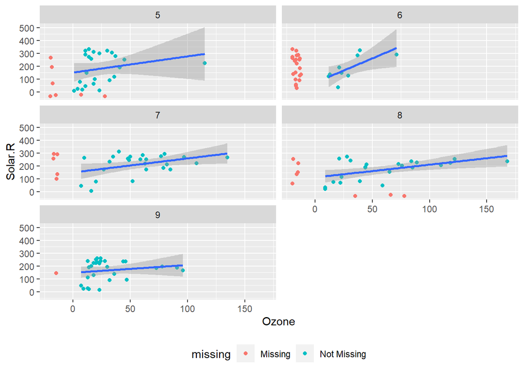

```r
# Missing data faceted by Month - represented by number. What pattern are we seeing now?
# 5 = May, 6 = June, 7 = July, 8 = August, 9 = September
ggplot(data = airquality_f,
       aes(x = Ozone,
           y = Solar.R)) +
  geom_miss_point() +
  geom_smooth(method = "lm") +
  facet_wrap(~Month, ncol = 2) +
  theme(legend.position = "bottom")
```

Looking at the plots, it seems like the warmer months tend to have an increased volume of missing Ozone data. And thankfully we have additional `auxillary` variables in our dataset to test this - namely the `Temp` and `Day` variables. Lets have a look at both:

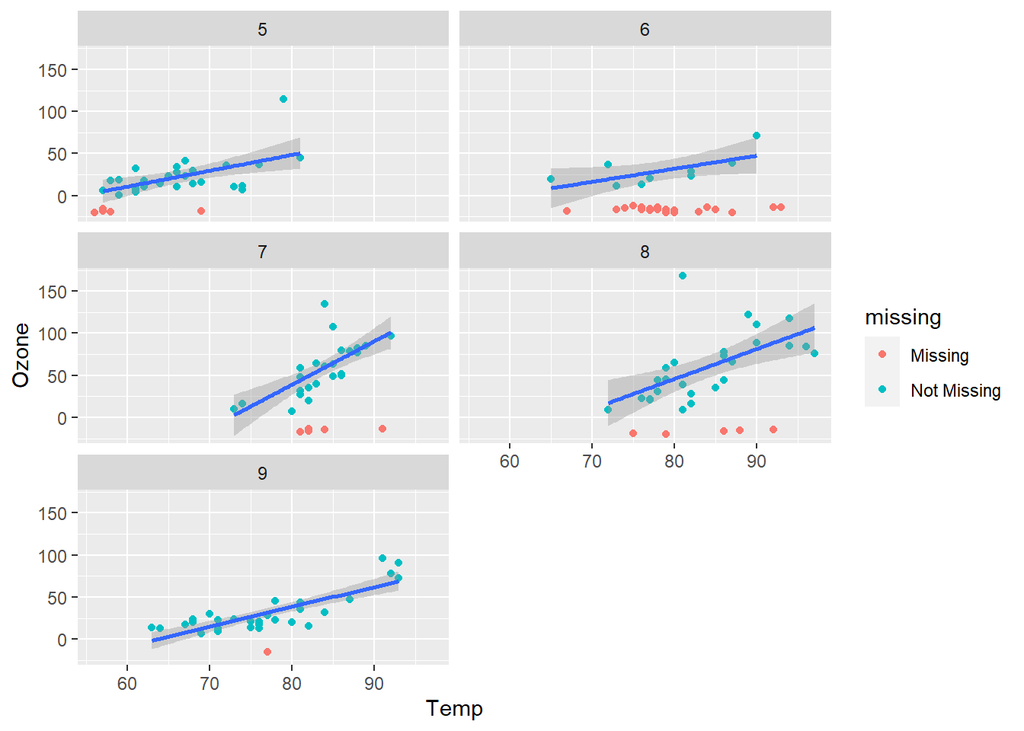

```r
ggplot(data = airquality_f,
       aes(x = Temp,
           y = Ozone)) +
  geom_miss_point() +
  geom_smooth(method = "lm") +
  facet_wrap(~Month, ncol = 2)
```

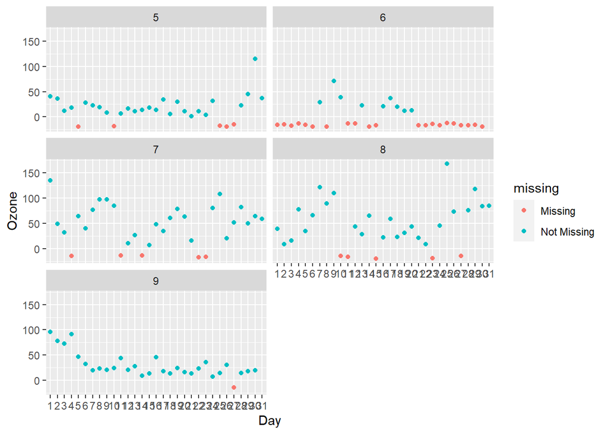

```r
ggplot(data = airquality_f,
       aes(x = Day,
           y = Ozone)) +
  geom_miss_point() +
  geom_smooth(method = "lm") +
  facet_wrap(~Month, ncol = 2)
```

By looking at the `Day` variable, we can also see how many variables appear to be missing within the 6th month - June. I suspect that this may have been the holiday month, and so data was not collected (this was pre-digitisation). So unfortunately, our missing data looks to be MNAR. This will make our life difficult - especially as we do not have any additional auxillary variables to use.

So for now, let us have a quick look at another dataset - the `oceanbuoys` dataset from R. Here we want to examine the missing data from the `air_temp_c` variable. And for this, we can use some abstract thinking! This time by using the `bind_shadow()` function to give us the tools to explain the occurance of missing data via logistic regressions - (This may all sound very sci-fi, but basically we will test to what extent our variables can determine an NA in `air_temp_c`).

```r
#Step 1 - examine data
Ocean_shadow <- oceanbuoys %>% bind_shadow() %>% mutate(year = as.factor(year))
 summary(Ocean_shadow)
```

```
##    year        latitude        longitude        sea_temp_c      air_temp_c
##  1993:368   Min.   :-5.000   Min.   :-110.0   Min.   :21.60   Min.   :21.42
##  1997:368   1st Qu.:-2.000   1st Qu.:-110.0   1st Qu.:23.50   1st Qu.:23.26
##             Median :-1.000   Median :-102.5   Median :26.55   Median :24.52
##             Mean   :-1.375   Mean   :-102.5   Mean   :25.86   Mean   :25.03
##             3rd Qu.: 0.000   3rd Qu.: -95.0   3rd Qu.:28.21   3rd Qu.:27.08
##             Max.   : 0.000   Max.   : -95.0   Max.   :30.17   Max.   :28.50
##                                               NA's   :3       NA's   :81
##     humidity        wind_ew          wind_ns       year_NA   latitude_NA
##  Min.   :71.60   Min.   :-8.100   Min.   :-6.200   !NA:736   !NA:736
##  1st Qu.:81.30   1st Qu.:-5.100   1st Qu.: 1.500   NA :  0   NA :  0
##  Median :85.20   Median :-3.900   Median : 2.900
##  Mean   :84.43   Mean   :-3.716   Mean   : 2.636
##  3rd Qu.:88.10   3rd Qu.:-2.600   3rd Qu.: 4.100
##  Max.   :94.80   Max.   : 4.300   Max.   : 7.300
##  NA's   :93
##  longitude_NA sea_temp_c_NA air_temp_c_NA humidity_NA wind_ew_NA wind_ns_NA
##  !NA:736      !NA:733       !NA:655       !NA:643     !NA:736    !NA:736
##  NA :  0      NA :  3       NA : 81       NA : 93     NA :  0    NA :  0
##
##
##
##
##
```

```r
# Step 2- logistic regression to test missing data hypothesis + data vis

 model_log<- glm(air_temp_c_NA ~ sea_temp_c, family="binomial", data = Ocean_shadow )

 summary(model_log)
```

```
##
## Call:
## glm(formula = air_temp_c_NA ~ sea_temp_c, family = "binomial",
##     data = Ocean_shadow)
##
## Coefficients:
##             Estimate Std. Error z value Pr(>|z|)
## (Intercept) -27.4643     3.9295  -6.989 2.76e-12 ***
## sea_temp_c    0.9232     0.1388   6.652 2.90e-11 ***
## ---
## Signif. codes:  0 '***' 0.001 '**' 0.01 '*' 0.05 '.' 0.1 ' ' 1
##
## (Dispersion parameter for binomial family taken to be 1)
##
##     Null deviance: 496.90  on 732  degrees of freedom
## Residual deviance: 373.31  on 731  degrees of freedom
##   (3 observations deleted due to missingness)
## AIC: 377.31
##
## Number of Fisher Scoring iterations: 7
```

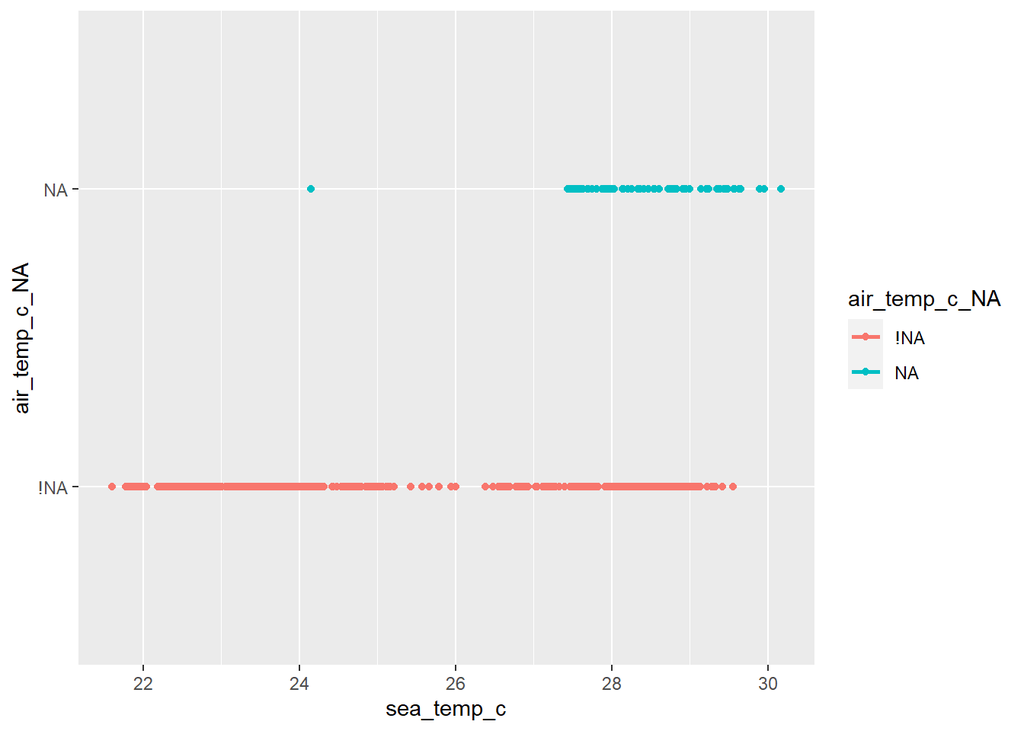

```r
ggplot(Ocean_shadow, aes(y = air_temp_c_NA, color = air_temp_c_NA, x = sea_temp_c)) +
  geom_point()+
  geom_smooth(method="glm", formula = y ~ x, method.args = list(family = "binomial"), se = FALSE)
```

```r
# Regression to test predictive capacity
 model_lm<- lm(air_temp_c ~ sea_temp_c, Ocean_shadow)
 summary(model_lm)
```

```
##
## Call:
## lm(formula = air_temp_c ~ sea_temp_c, data = Ocean_shadow)
##
## Residuals:
##     Min      1Q  Median      3Q     Max
## -1.9901 -0.1850  0.0513  0.2556  0.9295
##
## Coefficients:
##             Estimate Std. Error t value Pr(>|t|)
## (Intercept) 4.124825   0.164335    25.1   <2e-16 ***
## sea_temp_c  0.817808   0.006401   127.8   <2e-16 ***
## ---
## Signif. codes:  0 '***' 0.001 '**' 0.01 '*' 0.05 '.' 0.1 ' ' 1
##
## Residual standard error: 0.3926 on 653 degrees of freedom
##   (81 observations deleted due to missingness)
## Multiple R-squared:  0.9615, Adjusted R-squared:  0.9615
## F-statistic: 1.632e+04 on 1 and 653 DF,  p-value: < 2.2e-16
```

So our model isn’t perfect. But for demonstration purposes today it does the trick! And we can see that information on sea temperature explains the missingness of air temperature.

Not only can we use `bind_shadow()` to examine our data, but we can also use the `bind_shadow()` function to visualize and examine our imputation strategies. We will cover this in greater depth later, but for now here is a quick example using a linear model for imputing (have a think about how effective this strategy might be from looking at the plot).

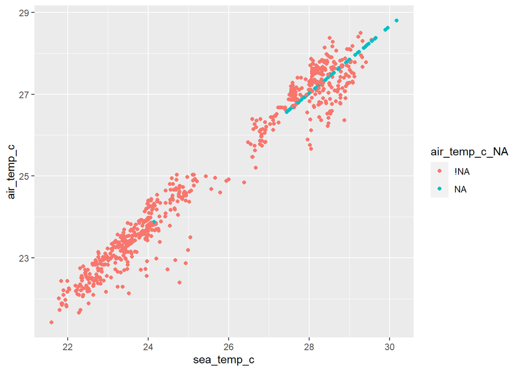

```r
oceanbuoys %>%
  bind_shadow() %>%
  as.data.frame() %>%
   impute_lm(air_temp_c ~ sea_temp_c) %>% # Here we are using the impute_lm function from the simputation package to impute our missing variables. Better methods will be applied later.
  ggplot(aes(x = sea_temp_c,
             y = air_temp_c,
             colour = air_temp_c_NA)) +
  geom_point()
```

Look at our imputed data along with the original data! Also notice how the linear regression imputation is not exactly perfect - the imputed data is over-fitted, as the imputed points are for too straight.

Better approaches will be examined next week. However, first we are going to dive into understanding how *different* missing data approaches affect our *different* types of missing data in many *different* ways!

## Dealing with missing data

Under all 3 conditions of missing data, we will artificially remove 30% of their data. This will be achieved using the `missMethods` package.

The aim of this section of the workshop is to work through what I call “So what?”. Here we will understand how the different choices to dealing with missing data interact with the types of missing data. We will work with each category of missing data, and with a set of missing data treatment options each time: deletion, mean-imputation, regression imputation, predictive mean matching multiple imputation. I know some of these names might be scary, and we will cover them. But the aim here is We will then visually analyse how each methods affects our data.

Here we will use the workhorse of data training examples to visualise the effects: iris. Here’s a little reminder of iris:

```r
#Here we are establishing our tables of the original data. We will use this to compare later. I realise some of the code might look a little complicated (i.e., `tbl_summary()`). But it's purpose here is to provide an easy to interpret table for us to navigate some awkward theory.

original_summary <- iris %>% tbl_summary( statistic = list(
      all_continuous() ~ "{mean} ({sd})",
      all_categorical() ~ "{n} / {N} ({p}%)"
    ))

original_summary
```

| **Characteristic** | **N = 150**<sup>1</sup> |
| --- | --- |
| Sepal.Length | 5.84 (0.83) |
| Sepal.Width | 3.06 (0.44) |
| Petal.Length | 3.76 (1.77) |
| Petal.Width | 1.20 (0.76) |
| Species |  |
| setosa | 50 / 150 (33%) |
| versicolor | 50 / 150 (33%) |
| virginica | 50 / 150 (33%) |

<sup>1</sup> Mean (SD); n / N (%)

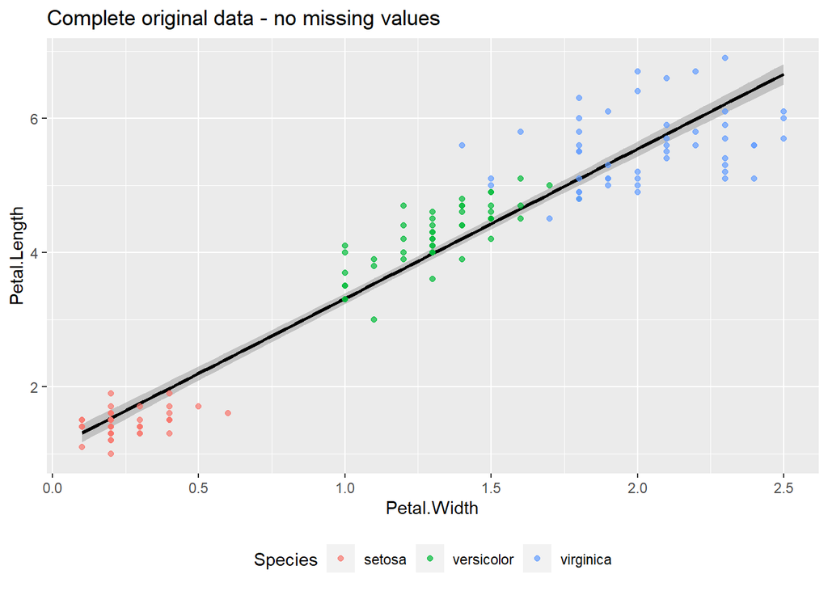

```r
vis_complete <- ggplot(iris, aes(x = Petal.Width, y = Petal.Length)) +
    geom_smooth(method = "lm", formula = y ~ x, color = "black", alpha = .5) +
  geom_point(aes(color = Species), alpha = .7)+
  theme(legend.position = "bottom") +
  labs(title = "Complete original data - no missing values")

vis_complete
```

```r
model_complete <- lm(Petal.Length ~ Petal.Width, iris) #establishing regression table

Original_model <- tbl_regression(model_complete)  %>%  #creating easy to interpret regression output using gtsummary functions.
  modify_column_unhide(column = std.error)  %>%
  add_glance_table(include = c(r.squared, adj.r.squared,
                               statistic, df.residual, p.value))

Original_model
```

| **Characteristic** | **Beta** | **SE**<sup>1</sup> | **95% CI**<sup>1</sup> | **p-value** |
| --- | --- | --- | --- | --- |
| Petal.Width | 2.2 | 0.051 | 2.1, 2.3 | <0.001 |
| R² | 0.927 |  |  |  |
| Adjusted R² | 0.927 |  |  |  |
| Statistic | 1,882 |  |  |  |
| Residual df | 148 |  |  |  |
| p-value | <0.001 |  |  |  |

<sup>1</sup> SE = Standard Error, CI = Confidence Interval

As the association between `Petal.Width` and `Petal.Length` is so striking, we will focus on these variables for the workshop. Notice also that there are no NA’s present. This makes it perfect for us to simulate and compare across the different missing categories.

First off, we will examine MCAR.

## MCAR missing data

Initially, we will examine and compare our plot and regression output between the complete data and the missing data. Notice how there isn’t much difference between the two.

```r
MCAR_iris <- delete_MCAR(iris, cols_mis = "Petal.Length", .3) %>% bind_shadow()# here we have asked data to be missing in the `Petal.Length` variable, and for 30% of data to be missing in a MCAR condition.
MCAR_summary <- MCAR_iris %>%
  dplyr::select(`Sepal.Length`, `Sepal.Width`, `Petal.Length`, `Petal.Width`, `Species`) %>% # selecting to avoid summaries of shadow variables.
  tbl_summary( statistic = list(
      all_continuous() ~ "{mean} ({sd})",
      all_categorical() ~ "{n} / {N} ({p}%)"
    ))

tbl_merge(tbls = list(original_summary, MCAR_summary),
          tab_spanner = c("Original", "MCAR")) # using to compare summaries of original and missing data.
```

| **Characteristic** | Original **N = 150**<sup>1</sup> | MCAR **N = 150**<sup>1</sup> |
| --- | --- | --- |
| Sepal.Length | 5.84 (0.83) | 5.84 (0.83) |
| Sepal.Width | 3.06 (0.44) | 3.06 (0.44) |
| Petal.Length | 3.76 (1.77) | 3.71 (1.80) |
| Unknown |  | 45 |
| Petal.Width | 1.20 (0.76) | 1.20 (0.76) |
| Species |  |  |
| setosa | 50 / 150 (33%) | 50 / 150 (33%) |
| versicolor | 50 / 150 (33%) | 50 / 150 (33%) |
| virginica | 50 / 150 (33%) | 50 / 150 (33%) |

<sup>1</sup> Mean (SD); n / N (%)

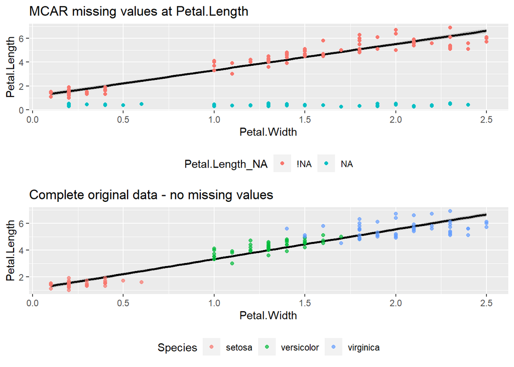

```r
vis_MCAR <- ggplot(MCAR_iris, aes(x = Petal.Width, y = Petal.Length, color = Petal.Length_NA)) +
    geom_smooth(method = "lm", formula = y ~ x, color = "black", alpha = .5) +
  geom_point(alpha = .7)+
  geom_miss_point() + # using grid_miss_point() from earlier to view difference
  theme(legend.position = "bottom") +
  labs(title = "MCAR missing values at Petal.Length")

grid.arrange(vis_MCAR, vis_complete) # Using grid.arrange() to compare plots, lets see the difference between a full data, and MCAR data
```

```r
model_MCAR <- lm(Petal.Length ~ Petal.Width, MCAR_iris) # Establishing model

# This next bit of code uses the gtsummary functions. It's very cool in creating quick tables, and definetly worth exploring in your own time. But for today their purpose is to allow us to quickly compare regression outputs



MCAR <- tbl_regression(model_MCAR) %>%
  modify_column_unhide(column = std.error) %>%
  add_glance_table(include = c(r.squared, adj.r.squared,
                               statistic, df.residual, p.value))

tbl_merge(tbls = list(Original_model, MCAR),
          tab_spanner = c("Original", "MCAR"))
```

| **Characteristic** | Original **Beta** | Original **SE**<sup>1</sup> | Original **95% CI**<sup>1</sup> | Original **p-value** | MCAR **Beta** | MCAR **SE**<sup>1</sup> | MCAR **95% CI**<sup>1</sup> | MCAR **p-value** |
| --- | --- | --- | --- | --- | --- | --- | --- | --- |
| Petal.Width | 2.2 | 0.051 | 2.1, 2.3 | <0.001 | 2.2 | 0.060 | 2.1, 2.3 | <0.001 |
| R² | 0.927 |  |  |  | 0.929 |  |  |  |
| Adjusted R² | 0.927 |  |  |  | 0.928 |  |  |  |
| Statistic | 1,882 |  |  |  | 1,346 |  |  |  |
| Residual df | 148 |  |  |  | 103 |  |  |  |
| p-value | <0.001 |  |  |  | <0.001 |  |  |  |

<sup>1</sup> SE = Standard Error, CI = Confidence Interval

### Deletion

```r
# Here we use the na.omit() function to remove our missing data
delete_MCAR <- MCAR_iris %>% na.omit()

MCAR_del_summary <- delete_MCAR %>%
  dplyr::select(`Sepal.Length`, `Sepal.Width`, `Petal.Length`, `Petal.Width`, `Species`) %>% # selecting to avoid summaries of shadow variables.
  tbl_summary( statistic = list(
      all_continuous() ~ "{mean} ({sd})",
      all_categorical() ~ "{n} / {N} ({p}%)"
    ))

tbl_merge(tbls = list(original_summary, MCAR_summary, MCAR_del_summary),
          tab_spanner = c("Original", "MCAR", "MCAR deleted missing")) # using to compare summaries of original and missing data.
```

| **Characteristic** | Original **N = 150**<sup>1</sup> | MCAR **N = 150**<sup>1</sup> | MCAR deleted missing **N = 105**<sup>1</sup> |
| --- | --- | --- | --- |
| Sepal.Length | 5.84 (0.83) | 5.84 (0.83) | 5.84 (0.87) |
| Sepal.Width | 3.06 (0.44) | 3.06 (0.44) | 3.07 (0.41) |
| Petal.Length | 3.76 (1.77) | 3.71 (1.80) | 3.71 (1.80) |
| Unknown |  | 45 |  |
| Petal.Width | 1.20 (0.76) | 1.20 (0.76) | 1.18 (0.78) |
| Species |  |  |  |
| setosa | 50 / 150 (33%) | 50 / 150 (33%) | 37 / 105 (35%) |
| versicolor | 50 / 150 (33%) | 50 / 150 (33%) | 34 / 105 (32%) |
| virginica | 50 / 150 (33%) | 50 / 150 (33%) | 34 / 105 (32%) |

<sup>1</sup> Mean (SD); n / N (%)

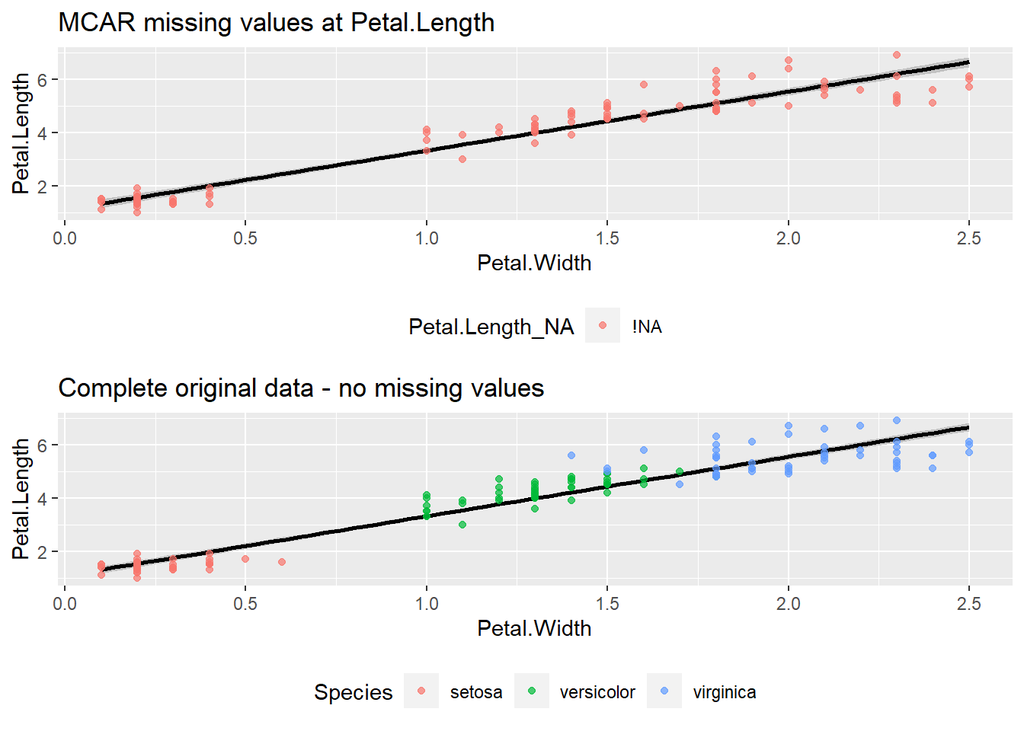

```r
vis_MCAR_delete <- ggplot(delete_MCAR, aes(x = Petal.Width, y = Petal.Length)) +
    geom_smooth(method = "lm", formula = y ~ x, color = "black", alpha = .5) +
  geom_point(aes(color = Petal.Length_NA), alpha =.7)+
  theme(legend.position = "bottom") +
  labs(title = "MCAR missing values at Petal.Length")

grid.arrange(vis_MCAR_delete, vis_complete) # Using grid.arrange() to compare plots, lets see the difference between a full data, and MCAR data
```

```r
model_MCAR_del <- lm(Petal.Length ~ Petal.Width, delete_MCAR) # Establishing model




MCAR_del <- tbl_regression(model_MCAR_del) %>%
  modify_column_unhide(column = std.error) %>%
  add_glance_table(include = c(r.squared, adj.r.squared,
                               statistic, df.residual, p.value))

tbl_merge(tbls = list(Original_model, MCAR, MCAR_del),
          tab_spanner = c("Original", "MCAR", "MCAR missing deleted"))
```

| **Characteristic** | Original **Beta** | Original **SE**<sup>1</sup> | Original **95% CI**<sup>1</sup> | Original **p-value** | MCAR **Beta** | MCAR **SE**<sup>1</sup> | MCAR **95% CI**<sup>1</sup> | MCAR **p-value** | MCAR missing deleted **Beta** | MCAR missing deleted **SE**<sup>1</sup> | MCAR missing deleted **95% CI**<sup>1</sup> | MCAR missing deleted **p-value** |
| --- | --- | --- | --- | --- | --- | --- | --- | --- | --- | --- | --- | --- |
| Petal.Width | 2.2 | 0.051 | 2.1, 2.3 | <0.001 | 2.2 | 0.060 | 2.1, 2.3 | <0.001 | 2.2 | 0.060 | 2.1, 2.3 | <0.001 |
| R² | 0.927 |  |  |  | 0.929 |  |  |  | 0.929 |  |  |  |
| Adjusted R² | 0.927 |  |  |  | 0.928 |  |  |  | 0.928 |  |  |  |
| Statistic | 1,882 |  |  |  | 1,346 |  |  |  | 1,346 |  |  |  |
| Residual df | 148 |  |  |  | 103 |  |  |  | 103 |  |  |  |
| p-value | <0.001 |  |  |  | <0.001 |  |  |  | <0.001 |  |  |  |

<sup>1</sup> SE = Standard Error, CI = Confidence Interval

So here we see little change - but notice how deleting missing variables from Petal.Length has impacted the means in other variables. Thankfully it is subtle under MCAR conditions. But it is worth being aware of this.

### Mean imputation.

```r
# Here we use the impute_mean() function to impute the mean values to our Petal.Length variable.

mean_imp_MCAR <- MCAR_iris %>% impute_mean()

MCAR_mean_imp_summary <- mean_imp_MCAR %>%
  dplyr::select(`Sepal.Length`, `Sepal.Width`, `Petal.Length`, `Petal.Width`, `Species`) %>% # selecting to avoid summaries of shadow variables.
  tbl_summary( statistic = list(
      all_continuous() ~ "{mean} ({sd})",
      all_categorical() ~ "{n} / {N} ({p}%)"
    ))

tbl_merge(tbls = list(original_summary, MCAR_summary, MCAR_del_summary, MCAR_mean_imp_summary),
          tab_spanner = c("Original", "MCAR", "MCAR deleted missing", "MCAR mean imputed")) # using to compare summaries of original and missing data.
```

| **Characteristic** | Original **N = 150**<sup>1</sup> | MCAR **N = 150**<sup>1</sup> | MCAR deleted missing **N = 105**<sup>1</sup> | MCAR mean imputed **N = 150**<sup>1</sup> |
| --- | --- | --- | --- | --- |
| Sepal.Length | 5.84 (0.83) | 5.84 (0.83) | 5.84 (0.87) | 5.84 (0.83) |
| Sepal.Width | 3.06 (0.44) | 3.06 (0.44) | 3.07 (0.41) | 3.06 (0.44) |
| Petal.Length | 3.76 (1.77) | 3.71 (1.80) | 3.71 (1.80) | 3.71 (1.50) |
| Unknown |  | 45 |  |  |
| Petal.Width | 1.20 (0.76) | 1.20 (0.76) | 1.18 (0.78) | 1.20 (0.76) |
| Species |  |  |  |  |
| setosa | 50 / 150 (33%) | 50 / 150 (33%) | 37 / 105 (35%) | 50 / 150 (33%) |
| versicolor | 50 / 150 (33%) | 50 / 150 (33%) | 34 / 105 (32%) | 50 / 150 (33%) |
| virginica | 50 / 150 (33%) | 50 / 150 (33%) | 34 / 105 (32%) | 50 / 150 (33%) |

<sup>1</sup> Mean (SD); n / N (%)

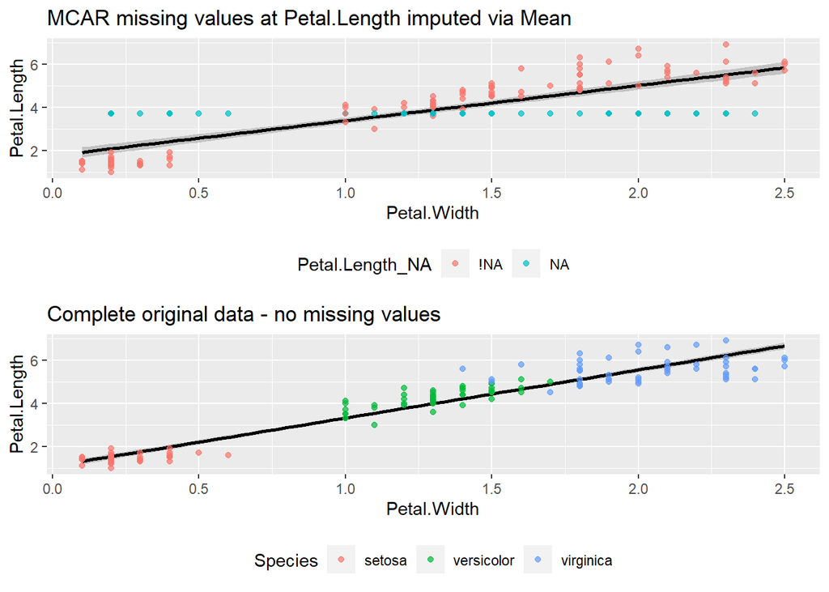

```r
vis_mean_imp <- ggplot(mean_imp_MCAR, aes(x = Petal.Width, y = Petal.Length)) +
    geom_smooth(method = "lm", formula = y ~ x, color = "black", alpha = .5) +
  geom_point(aes(color = Petal.Length_NA), alpha =.7)+
  theme(legend.position = "bottom") +
  labs(title = "MCAR missing values at Petal.Length imputed via Mean")

grid.arrange(vis_mean_imp, vis_complete) # Using grid.arrange() to compare plots, lets see the difference between a full data, and MCAR data
```

```r
model_MCAR_imp <- lm(Petal.Length ~ Petal.Width, mean_imp_MCAR) # Establishing model




MCAR_mean_imp <- tbl_regression(model_MCAR_imp) %>%
  modify_column_unhide(column = std.error) %>%
  add_glance_table(include = c(r.squared, adj.r.squared,
                               statistic, df.residual, p.value))

tbl_merge(tbls = list(Original_model, MCAR, MCAR_del, MCAR_mean_imp),
          tab_spanner = c("Original", "MCAR", "MCAR missing deleted", "MCAR mean imputation"))
```

| **Characteristic** | Original **Beta** | Original **SE**<sup>1</sup> | Original **95% CI**<sup>1</sup> | Original **p-value** | MCAR **Beta** | MCAR **SE**<sup>1</sup> | MCAR **95% CI**<sup>1</sup> | MCAR **p-value** | MCAR missing deleted **Beta** | MCAR missing deleted **SE**<sup>1</sup> | MCAR missing deleted **95% CI**<sup>1</sup> | MCAR missing deleted **p-value** | MCAR mean imputation **Beta** | MCAR mean imputation **SE**<sup>1</sup> | MCAR mean imputation **95% CI**<sup>1</sup> | MCAR mean imputation **p-value** |
| --- | --- | --- | --- | --- | --- | --- | --- | --- | --- | --- | --- | --- | --- | --- | --- | --- |
| Petal.Width | 2.2 | 0.051 | 2.1, 2.3 | <0.001 | 2.2 | 0.060 | 2.1, 2.3 | <0.001 | 2.2 | 0.060 | 2.1, 2.3 | <0.001 | 1.6 | 0.091 | 1.4, 1.8 | <0.001 |
| R² | 0.927 |  |  |  | 0.929 |  |  |  | 0.929 |  |  |  | 0.685 |  |  |  |
| Adjusted R² | 0.927 |  |  |  | 0.928 |  |  |  | 0.928 |  |  |  | 0.683 |  |  |  |
| Statistic | 1,882 |  |  |  | 1,346 |  |  |  | 1,346 |  |  |  | 321 |  |  |  |
| Residual df | 148 |  |  |  | 103 |  |  |  | 103 |  |  |  | 148 |  |  |  |
| p-value | <0.001 |  |  |  | <0.001 |  |  |  | <0.001 |  |  |  | <0.001 |  |  |  |

<sup>1</sup> SE = Standard Error, CI = Confidence Interval

### Linear regression imputation.

```r
# Here we use the impute_lm() function to impute via regression
lm_imp_MCAR <- MCAR_iris %>% impute_lm(Petal.Length ~ Petal.Width)

MCAR_lm_imp_summary <- lm_imp_MCAR %>%
  dplyr::select(`Sepal.Length`, `Sepal.Width`, `Petal.Length`, `Petal.Width`, `Species`) %>% # selecting to avoid summaries of shadow variables.
  tbl_summary( statistic = list(
      all_continuous() ~ "{mean} ({sd})",
      all_categorical() ~ "{n} / {N} ({p}%)"
    ))

tbl_merge(tbls = list(original_summary, MCAR_summary, MCAR_del_summary, MCAR_mean_imp_summary, MCAR_lm_imp_summary),
          tab_spanner = c("Original", "MCAR", "MCAR deleted missing", "MCAR mean imputed", "MCAR linear model imp")) # using to compare summaries of original and missing data.
```

| **Characteristic** | Original **N = 150**<sup>1</sup> | MCAR **N = 150**<sup>1</sup> | MCAR deleted missing **N = 105**<sup>1</sup> | MCAR mean imputed **N = 150**<sup>1</sup> | MCAR linear model imp **N = 150**<sup>1</sup> |
| --- | --- | --- | --- | --- | --- |
| Sepal.Length | 5.84 (0.83) | 5.84 (0.83) | 5.84 (0.87) | 5.84 (0.83) | 5.84 (0.83) |
| Sepal.Width | 3.06 (0.44) | 3.06 (0.44) | 3.07 (0.41) | 3.06 (0.44) | 3.06 (0.44) |
| Petal.Length | 3.76 (1.77) | 3.71 (1.80) | 3.71 (1.80) | 3.71 (1.50) | 3.76 (1.73) |
| Unknown |  | 45 |  |  |  |
| Petal.Width | 1.20 (0.76) | 1.20 (0.76) | 1.18 (0.78) | 1.20 (0.76) | 1.20 (0.76) |
| Species |  |  |  |  |  |
| setosa | 50 / 150 (33%) | 50 / 150 (33%) | 37 / 105 (35%) | 50 / 150 (33%) | 50 / 150 (33%) |
| versicolor | 50 / 150 (33%) | 50 / 150 (33%) | 34 / 105 (32%) | 50 / 150 (33%) | 50 / 150 (33%) |
| virginica | 50 / 150 (33%) | 50 / 150 (33%) | 34 / 105 (32%) | 50 / 150 (33%) | 50 / 150 (33%) |

<sup>1</sup> Mean (SD); n / N (%)

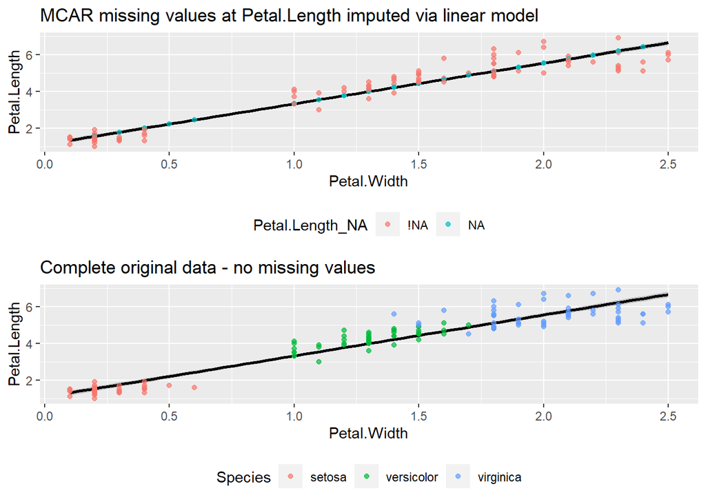

```r
vis_lm_imp <- ggplot(lm_imp_MCAR, aes(x = Petal.Width, y = Petal.Length)) +
  geom_smooth(method = "lm", formula = y ~ x, color = "black", alpha = .5) +
  geom_point(aes(color = Petal.Length_NA), alpha = .7)+
  theme(legend.position = "bottom") +
  labs(title = "MCAR missing values at Petal.Length imputed via linear model")

grid.arrange(vis_lm_imp, vis_complete) # Using grid.arrange() to compare plots, lets see the difference between a full data, and MCAR data
```

```r
model_MCAR_lm_imp <- lm(Petal.Length ~ Petal.Width, lm_imp_MCAR) # Establishing model




MCAR_lm_imp <- tbl_regression(model_MCAR_lm_imp) %>%
  modify_column_unhide(column = std.error) %>%
  add_glance_table(include = c(r.squared, adj.r.squared,
                               statistic, df.residual, p.value))

tbl_merge(tbls = list(Original_model, MCAR, MCAR_del, MCAR_mean_imp, MCAR_lm_imp),
          tab_spanner = c("Original", "MCAR", "MCAR missing deleted", "MCAR mean imputation", "MCAR linear model imputation"))
```

| **Characteristic** | Original **Beta** | Original **SE**<sup>1</sup> | Original **95% CI**<sup>1</sup> | Original **p-value** | MCAR **Beta** | MCAR **SE**<sup>1</sup> | MCAR **95% CI**<sup>1</sup> | MCAR **p-value** | MCAR missing deleted **Beta** | MCAR missing deleted **SE**<sup>1</sup> | MCAR missing deleted **95% CI**<sup>1</sup> | MCAR missing deleted **p-value** | MCAR mean imputation **Beta** | MCAR mean imputation **SE**<sup>1</sup> | MCAR mean imputation **95% CI**<sup>1</sup> | MCAR mean imputation **p-value** | MCAR linear model imputation **Beta** | MCAR linear model imputation **SE**<sup>1</sup> | MCAR linear model imputation **95% CI**<sup>1</sup> | MCAR linear model imputation **p-value** |
| --- | --- | --- | --- | --- | --- | --- | --- | --- | --- | --- | --- | --- | --- | --- | --- | --- | --- | --- | --- | --- |
| Petal.Width | 2.2 | 0.051 | 2.1, 2.3 | <0.001 | 2.2 | 0.060 | 2.1, 2.3 | <0.001 | 2.2 | 0.060 | 2.1, 2.3 | <0.001 | 1.6 | 0.091 | 1.4, 1.8 | <0.001 | 2.2 | 0.043 | 2.1, 2.3 | <0.001 |
| R² | 0.927 |  |  |  | 0.929 |  |  |  | 0.929 |  |  |  | 0.685 |  |  |  | 0.947 |  |  |  |
| Adjusted R² | 0.927 |  |  |  | 0.928 |  |  |  | 0.928 |  |  |  | 0.683 |  |  |  | 0.946 |  |  |  |
| Statistic | 1,882 |  |  |  | 1,346 |  |  |  | 1,346 |  |  |  | 321 |  |  |  | 2,624 |  |  |  |
| Residual df | 148 |  |  |  | 103 |  |  |  | 103 |  |  |  | 148 |  |  |  | 148 |  |  |  |
| p-value | <0.001 |  |  |  | <0.001 |  |  |  | <0.001 |  |  |  | <0.001 |  |  |  | <0.001 |  |  |  |

<sup>1</sup> SE = Standard Error, CI = Confidence Interval

We see that the issue here is the linear model imputation method fits a little too well - We have yet to hit the Goldilocks zone of “just right”. This is can be seen in the plots, but also through the R square and Adjusted R square increasing in value. So we need a method of imputing that is realistic, but can add some noise to avoid over-fitting/falsely inflating our analysis.

For this we will use the predictive mean matching (pmm) within a multiple imputed chained equation setup - Again, this is all very fancy speak, which we will cover in detail next week. But for today, it is good to know that this is one of the recommended best practice approaches.

### PMM - predicitive mean matching

```r
pmm_MCAR <- mice(MCAR_iris, method = "pmm", m =5, maxit = 5, seed = 123, print = FALSE)
pmm_MCAR_complete <- complete(pmm_MCAR, 5) # Please note this is a simplified approach, and that best practice requires pool and testing against a model. However, as a demonstration it is still effective.
```

```r
MCAR_pmm_imp_summary <- pmm_MCAR_complete %>%
  dplyr::select(`Sepal.Length`, `Sepal.Width`, `Petal.Length`, `Petal.Width`, `Species`) %>% # selecting to avoid summaries of shadow variables.
  tbl_summary( statistic = list(
      all_continuous() ~ "{mean} ({sd})",
      all_categorical() ~ "{n} / {N} ({p}%)"
    ))

tbl_merge(tbls = list(original_summary, MCAR_summary, MCAR_del_summary, MCAR_mean_imp_summary, MCAR_lm_imp_summary, MCAR_pmm_imp_summary),
          tab_spanner = c("Original", "MCAR", "MCAR deleted missing", "MCAR mean imputed", "MCAR linear model imp", "MCAR pmm imputed")) # using to compare summaries of original and missing data.
```

| **Characteristic** | Original **N = 150**<sup>1</sup> | MCAR **N = 150**<sup>1</sup> | MCAR deleted missing **N = 105**<sup>1</sup> | MCAR mean imputed **N = 150**<sup>1</sup> | MCAR linear model imp **N = 150**<sup>1</sup> | MCAR pmm imputed **N = 150**<sup>1</sup> |
| --- | --- | --- | --- | --- | --- | --- |
| Sepal.Length | 5.84 (0.83) | 5.84 (0.83) | 5.84 (0.87) | 5.84 (0.83) | 5.84 (0.83) | 5.84 (0.83) |
| Sepal.Width | 3.06 (0.44) | 3.06 (0.44) | 3.07 (0.41) | 3.06 (0.44) | 3.06 (0.44) | 3.06 (0.44) |
| Petal.Length | 3.76 (1.77) | 3.71 (1.80) | 3.71 (1.80) | 3.71 (1.50) | 3.76 (1.73) | 3.77 (1.78) |
| Unknown |  | 45 |  |  |  |  |
| Petal.Width | 1.20 (0.76) | 1.20 (0.76) | 1.18 (0.78) | 1.20 (0.76) | 1.20 (0.76) | 1.20 (0.76) |
| Species |  |  |  |  |  |  |
| setosa | 50 / 150 (33%) | 50 / 150 (33%) | 37 / 105 (35%) | 50 / 150 (33%) | 50 / 150 (33%) | 50 / 150 (33%) |
| versicolor | 50 / 150 (33%) | 50 / 150 (33%) | 34 / 105 (32%) | 50 / 150 (33%) | 50 / 150 (33%) | 50 / 150 (33%) |
| virginica | 50 / 150 (33%) | 50 / 150 (33%) | 34 / 105 (32%) | 50 / 150 (33%) | 50 / 150 (33%) | 50 / 150 (33%) |

<sup>1</sup> Mean (SD); n / N (%)

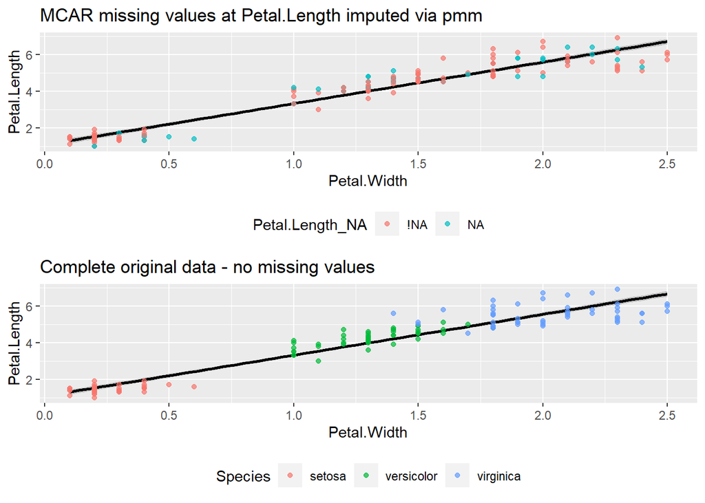

```r
vis_pmm_imp <- ggplot(pmm_MCAR_complete, aes(x = Petal.Width, y = Petal.Length)) +
    geom_smooth(method = "lm", formula = y ~ x, color = "black", alpha = .5) +
  geom_point(aes(color = Petal.Length_NA), alpha = .7)+
  theme(legend.position = "bottom") +
  labs(title = "MCAR missing values at Petal.Length imputed via pmm")

grid.arrange(vis_pmm_imp, vis_complete) # Using grid.arrange() to compare plots, lets see the difference between a full data, and MCAR data
```

```r
model_MCAR_pmm_imp <- lm(Petal.Length ~ Petal.Width, pmm_MCAR_complete) # Establishing model




MCAR_pmmm_imp <- tbl_regression(model_MCAR_pmm_imp) %>%
  modify_column_unhide(column = std.error) %>%
  add_glance_table(include = c(r.squared, adj.r.squared,
                               statistic, df.residual, p.value))

tbl_merge(tbls = list(Original_model, MCAR, MCAR_del, MCAR_mean_imp, MCAR_lm_imp, MCAR_pmmm_imp),
          tab_spanner = c("Original", "MCAR", "MCAR missing deleted", "MCAR mean imputation", "MCAR linear model imputation", "MCAR predictive mean matching imputation"))
```

| **Characteristic** | Original **Beta** | Original **SE**<sup>1</sup> | Original **95% CI**<sup>1</sup> | Original **p-value** | MCAR **Beta** | MCAR **SE**<sup>1</sup> | MCAR **95% CI**<sup>1</sup> | MCAR **p-value** | MCAR missing deleted **Beta** | MCAR missing deleted **SE**<sup>1</sup> | MCAR missing deleted **95% CI**<sup>1</sup> | MCAR missing deleted **p-value** | MCAR mean imputation **Beta** | MCAR mean imputation **SE**<sup>1</sup> | MCAR mean imputation **95% CI**<sup>1</sup> | MCAR mean imputation **p-value** | MCAR linear model imputation **Beta** | MCAR linear model imputation **SE**<sup>1</sup> | MCAR linear model imputation **95% CI**<sup>1</sup> | MCAR linear model imputation **p-value** | MCAR predictive mean matching imputation **Beta** | MCAR predictive mean matching imputation **SE**<sup>1</sup> | MCAR predictive mean matching imputation **95% CI**<sup>1</sup> | MCAR predictive mean matching imputation **p-value** |
| --- | --- | --- | --- | --- | --- | --- | --- | --- | --- | --- | --- | --- | --- | --- | --- | --- | --- | --- | --- | --- | --- | --- | --- | --- |
| Petal.Width | 2.2 | 0.051 | 2.1, 2.3 | <0.001 | 2.2 | 0.060 | 2.1, 2.3 | <0.001 | 2.2 | 0.060 | 2.1, 2.3 | <0.001 | 1.6 | 0.091 | 1.4, 1.8 | <0.001 | 2.2 | 0.043 | 2.1, 2.3 | <0.001 | 2.3 | 0.052 | 2.2, 2.4 | <0.001 |
| R² | 0.927 |  |  |  | 0.929 |  |  |  | 0.929 |  |  |  | 0.685 |  |  |  | 0.947 |  |  |  | 0.927 |  |  |  |
| Adjusted R² | 0.927 |  |  |  | 0.928 |  |  |  | 0.928 |  |  |  | 0.683 |  |  |  | 0.946 |  |  |  | 0.927 |  |  |  |
| Statistic | 1,882 |  |  |  | 1,346 |  |  |  | 1,346 |  |  |  | 321 |  |  |  | 2,624 |  |  |  | 1,883 |  |  |  |
| Residual df | 148 |  |  |  | 103 |  |  |  | 103 |  |  |  | 148 |  |  |  | 148 |  |  |  | 148 |  |  |  |
| p-value | <0.001 |  |  |  | <0.001 |  |  |  | <0.001 |  |  |  | <0.001 |  |  |  | <0.001 |  |  |  | <0.001 |  |  |  |

<sup>1</sup> SE = Standard Error, CI = Confidence Interval

So what do we see when comparing *PMM* to other methods? Well, it brings in an accurate prediction, but also with “noise” thrown in. As a result, the model does not over-fit in the way that *linear regression* imputation does. This certainly looks closer to the sweet spot.

Conclusion for best methods for *MCAR* data - deletion and *PMM* will have the smallest biasing impact under MCAR conditions. However, *PMM* allows for sample size to be protected. This can be invaluable when working with hard-to-reach samples.

## MAR missing data

```r
MAR_iris <- delete_MAR_censoring(iris, cols_mis = "Petal.Length", cols_ctrl = "Petal.Width", .3) %>% bind_shadow()# here we have asked data to be missing in the `Petal.Length` variable, and for 30% of data to be missing in a MAR condition.
MAR_summary <- MAR_iris %>%
  dplyr::select(`Sepal.Length`, `Sepal.Width`, `Petal.Length`, `Petal.Width`, `Species`) %>% # selecting to avoid summaries of shadow variables.
  tbl_summary( statistic = list(
      all_continuous() ~ "{mean} ({sd})",
      all_categorical() ~ "{n} / {N} ({p}%)"
    ))

tbl_merge(tbls = list(original_summary, MCAR_summary, MAR_summary),
          tab_spanner = c("Original", "MCAR","MAR")) # using to compare summaries of original and missing data.
```

| **Characteristic** | Original **N = 150**<sup>1</sup> | MCAR **N = 150**<sup>1</sup> | MAR **N = 150**<sup>1</sup> |
| --- | --- | --- | --- |
| Sepal.Length | 5.84 (0.83) | 5.84 (0.83) | 5.84 (0.83) |
| Sepal.Width | 3.06 (0.44) | 3.06 (0.44) | 3.06 (0.44) |
| Petal.Length | 3.76 (1.77) | 3.71 (1.80) | 4.75 (1.06) |
| Unknown |  | 45 | 45 |
| Petal.Width | 1.20 (0.76) | 1.20 (0.76) | 1.20 (0.76) |
| Species |  |  |  |
| setosa | 50 / 150 (33%) | 50 / 150 (33%) | 50 / 150 (33%) |
| versicolor | 50 / 150 (33%) | 50 / 150 (33%) | 50 / 150 (33%) |
| virginica | 50 / 150 (33%) | 50 / 150 (33%) | 50 / 150 (33%) |

<sup>1</sup> Mean (SD); n / N (%)

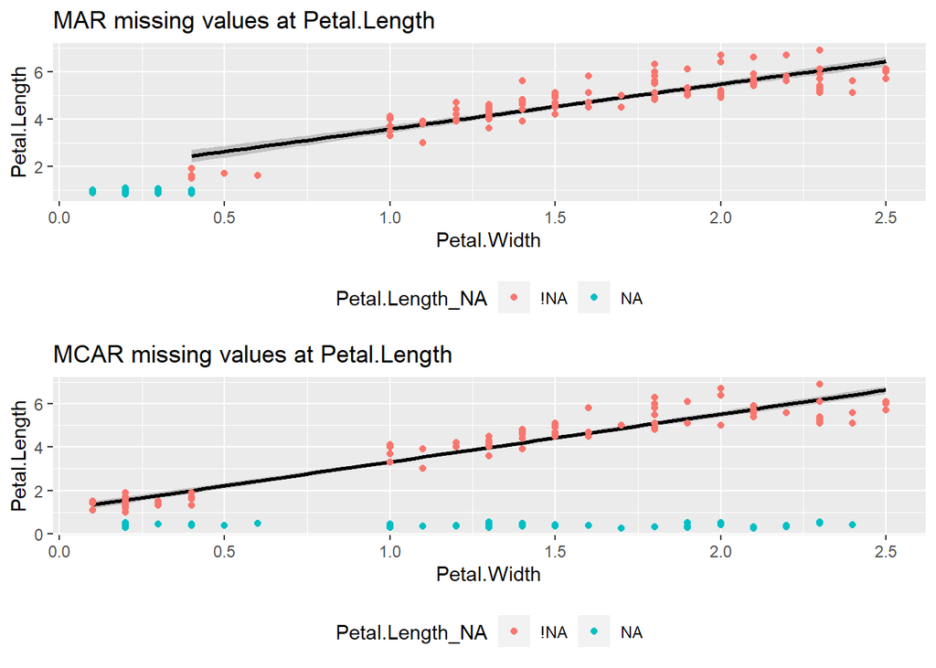

```r
vis_MAR <- ggplot(MAR_iris, aes(x = Petal.Width, y = Petal.Length, color = Petal.Length_NA)) +
    geom_smooth(method = "lm", formula = y ~ x, color = "black", alpha = .5) +
  geom_point(alpha =.7)+
  geom_miss_point() + # using grid_miss_point() from earlier to view difference
  theme(legend.position = "bottom") +
  labs(title = "MAR missing values at Petal.Length")

grid.arrange(vis_MAR,vis_MCAR) # Using grid.arrange() to compare plots, lets see the difference between a MAR data and MCAR data.
```

```r
model_MAR <- lm(Petal.Length ~ Petal.Width, MAR_iris) # Establishing model

# This next bit of code uses the gtsummary functions. It's very cool in creating quick tables, and definetly worth exploring in your own time. But for today their purpose is to allow us to quickly compare regression outputs



MAR <- tbl_regression(model_MAR) %>%
  modify_column_unhide(column = std.error) %>%
  add_glance_table(include = c(r.squared, adj.r.squared,
                               statistic, df.residual, p.value))

tbl_merge(tbls = list(Original_model, MCAR, MAR),
          tab_spanner = c("Original", "MCAR" ,"MAR"))
```

| **Characteristic** | Original **Beta** | Original **SE**<sup>1</sup> | Original **95% CI**<sup>1</sup> | Original **p-value** | MCAR **Beta** | MCAR **SE**<sup>1</sup> | MCAR **95% CI**<sup>1</sup> | MCAR **p-value** | MAR **Beta** | MAR **SE**<sup>1</sup> | MAR **95% CI**<sup>1</sup> | MAR **p-value** |
| --- | --- | --- | --- | --- | --- | --- | --- | --- | --- | --- | --- | --- |
| Petal.Width | 2.2 | 0.051 | 2.1, 2.3 | <0.001 | 2.2 | 0.060 | 2.1, 2.3 | <0.001 | 1.9 | 0.104 | 1.7, 2.1 | <0.001 |
| R² | 0.927 |  |  |  | 0.929 |  |  |  | 0.764 |  |  |  |
| Adjusted R² | 0.927 |  |  |  | 0.928 |  |  |  | 0.762 |  |  |  |
| Statistic | 1,882 |  |  |  | 1,346 |  |  |  | 334 |  |  |  |
| Residual df | 148 |  |  |  | 103 |  |  |  | 103 |  |  |  |
| p-value | <0.001 |  |  |  | <0.001 |  |  |  | <0.001 |  |  |  |

<sup>1</sup> SE = Standard Error, CI = Confidence Interval

We can see that the presence of MAR data has impact the analysis. The mean value of Petal.Length has increased, and the model predictive power has decreased.

### Deletion

```r
# Here we use the na.omit() function to remove our missing data
delete_MAR <- MAR_iris %>% na.omit()

MAR_del_summary <- delete_MAR %>%
  dplyr::select(`Sepal.Length`, `Sepal.Width`, `Petal.Length`, `Petal.Width`, `Species`) %>% # selecting to avoid summaries of shadow variables.
  tbl_summary( statistic = list(
      all_continuous() ~ "{mean} ({sd})",
      all_categorical() ~ "{n} / {N} ({p}%)"
    ))

tbl_merge(tbls = list(original_summary, MAR_summary, MAR_del_summary),
          tab_spanner = c("Original", "MAR", "MAR deleted missing")) # using to compare summaries of original and missing data.
```

| **Characteristic** | Original **N = 150**<sup>1</sup> | MAR **N = 150**<sup>1</sup> | MAR deleted missing **N = 105**<sup>1</sup> |
| --- | --- | --- | --- |
| Sepal.Length | 5.84 (0.83) | 5.84 (0.83) | 6.21 (0.69) |
| Sepal.Width | 3.06 (0.44) | 3.06 (0.44) | 2.90 (0.35) |
| Petal.Length | 3.76 (1.77) | 4.75 (1.06) | 4.75 (1.06) |
| Unknown |  | 45 |  |
| Petal.Width | 1.20 (0.76) | 1.20 (0.76) | 1.62 (0.49) |
| Species |  |  |  |
| setosa | 50 / 150 (33%) | 50 / 150 (33%) | 5 / 105 (4.8%) |
| versicolor | 50 / 150 (33%) | 50 / 150 (33%) | 50 / 105 (48%) |
| virginica | 50 / 150 (33%) | 50 / 150 (33%) | 50 / 105 (48%) |

<sup>1</sup> Mean (SD); n / N (%)

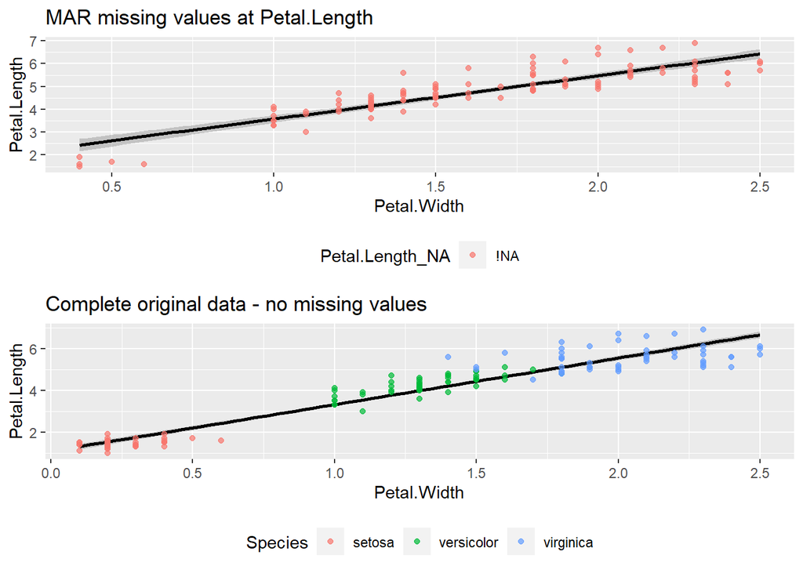

```r
vis_MAR_delete <- ggplot(delete_MAR, aes(x = Petal.Width, y = Petal.Length )) +
    geom_smooth(method = "lm", formula = y ~ x, color = "black", alpha = .5) +
  geom_point(aes(color = Petal.Length_NA), alpha =.7)+
  theme(legend.position = "bottom") +
  labs(title = "MAR missing values at Petal.Length")

grid.arrange(vis_MAR_delete, vis_complete) # Using grid.arrange() to compare plots, lets see the difference between a full data, and MCAR data
```

```r
model_MAR_del <- lm(Petal.Length ~ Petal.Width, delete_MAR) # Establishing model




MAR_del <- tbl_regression(model_MAR_del) %>%
  modify_column_unhide(column = std.error) %>%
  add_glance_table(include = c(r.squared, adj.r.squared,
                               statistic, df.residual, p.value))

tbl_merge(tbls = list(Original_model, MAR, MAR_del),
          tab_spanner = c("Original", "MAR", "MAR missing deleted"))
```

| **Characteristic** | Original **Beta** | Original **SE**<sup>1</sup> | Original **95% CI**<sup>1</sup> | Original **p-value** | MAR **Beta** | MAR **SE**<sup>1</sup> | MAR **95% CI**<sup>1</sup> | MAR **p-value** | MAR missing deleted **Beta** | MAR missing deleted **SE**<sup>1</sup> | MAR missing deleted **95% CI**<sup>1</sup> | MAR missing deleted **p-value** |
| --- | --- | --- | --- | --- | --- | --- | --- | --- | --- | --- | --- | --- |
| Petal.Width | 2.2 | 0.051 | 2.1, 2.3 | <0.001 | 1.9 | 0.104 | 1.7, 2.1 | <0.001 | 1.9 | 0.104 | 1.7, 2.1 | <0.001 |
| R² | 0.927 |  |  |  | 0.764 |  |  |  | 0.764 |  |  |  |
| Adjusted R² | 0.927 |  |  |  | 0.762 |  |  |  | 0.762 |  |  |  |
| Statistic | 1,882 |  |  |  | 334 |  |  |  | 334 |  |  |  |
| Residual df | 148 |  |  |  | 103 |  |  |  | 103 |  |  |  |
| p-value | <0.001 |  |  |  | <0.001 |  |  |  | <0.001 |  |  |  |

<sup>1</sup> SE = Standard Error, CI = Confidence Interval

Deleting every missing value provides similar results to ignoring every missing value - but notice how deleting missing variables from Petal.Length has again impacted the means in other variables. This can be exaggerated if data is missing across multiple variables.

### Mean imputation.

```r
# Here we use the impute_mean() function to impute the mean values to our Petal.Length variable.

mean_imp_MAR <- MAR_iris %>% impute_mean()

MAR_mean_imp_summary <- mean_imp_MAR %>%
  dplyr::select(`Sepal.Length`, `Sepal.Width`, `Petal.Length`, `Petal.Width`, `Species`) %>% # selecting to avoid summaries of shadow variables.
  tbl_summary( statistic = list(
      all_continuous() ~ "{mean} ({sd})",
      all_categorical() ~ "{n} / {N} ({p}%)"
    ))

tbl_merge(tbls = list(original_summary, MAR_summary, MAR_del_summary, MAR_mean_imp_summary),
          tab_spanner = c("Original", "MAR", "MAR deleted missing", "MAR mean imputed")) # using to compare summaries of original and missing data.
```

| **Characteristic** | Original **N = 150**<sup>1</sup> | MAR **N = 150**<sup>1</sup> | MAR deleted missing **N = 105**<sup>1</sup> | MAR mean imputed **N = 150**<sup>1</sup> |
| --- | --- | --- | --- | --- |
| Sepal.Length | 5.84 (0.83) | 5.84 (0.83) | 6.21 (0.69) | 5.84 (0.83) |
| Sepal.Width | 3.06 (0.44) | 3.06 (0.44) | 2.90 (0.35) | 3.06 (0.44) |
| Petal.Length | 3.76 (1.77) | 4.75 (1.06) | 4.75 (1.06) | 4.75 (0.89) |
| Unknown |  | 45 |  |  |
| Petal.Width | 1.20 (0.76) | 1.20 (0.76) | 1.62 (0.49) | 1.20 (0.76) |
| Species |  |  |  |  |
| setosa | 50 / 150 (33%) | 50 / 150 (33%) | 5 / 105 (4.8%) | 50 / 150 (33%) |
| versicolor | 50 / 150 (33%) | 50 / 150 (33%) | 50 / 105 (48%) | 50 / 150 (33%) |
| virginica | 50 / 150 (33%) | 50 / 150 (33%) | 50 / 105 (48%) | 50 / 150 (33%) |

<sup>1</sup> Mean (SD); n / N (%)

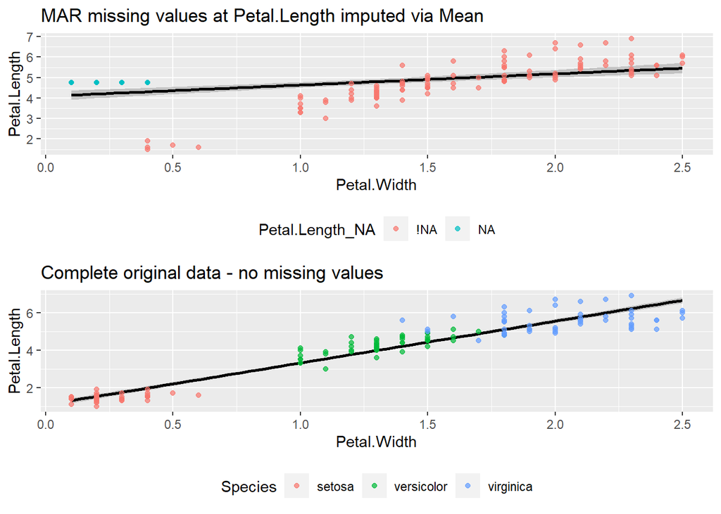

```r
vis_mean_imp <- ggplot(mean_imp_MAR, aes(x = Petal.Width, y = Petal.Length)) +
    geom_smooth(method = "lm", formula = y ~ x, color = "black", alpha = .5) +
  geom_point(aes(color = Petal.Length_NA), alpha =.7)+
  theme(legend.position = "bottom") +
  labs(title = "MAR missing values at Petal.Length imputed via Mean")

grid.arrange(vis_mean_imp, vis_complete) # Using grid.arrange() to compare plots, lets see the difference between a full data, and MCAR data
```

```r
model_MAR_imp <- lm(Petal.Length ~ Petal.Width, mean_imp_MAR) # Establishing model




MAR_mean_imp <- tbl_regression(model_MAR_imp) %>%
  modify_column_unhide(column = std.error) %>%
  add_glance_table(include = c(r.squared, adj.r.squared,
                               statistic, df.residual, p.value))

tbl_merge(tbls = list(Original_model, MAR, MAR_del, MAR_mean_imp),
          tab_spanner = c("Original", "MAR", "MAR missing deleted", "MAR mean imputation"))
```

| **Characteristic** | Original **Beta** | Original **SE**<sup>1</sup> | Original **95% CI**<sup>1</sup> | Original **p-value** | MAR **Beta** | MAR **SE**<sup>1</sup> | MAR **95% CI**<sup>1</sup> | MAR **p-value** | MAR missing deleted **Beta** | MAR missing deleted **SE**<sup>1</sup> | MAR missing deleted **95% CI**<sup>1</sup> | MAR missing deleted **p-value** | MAR mean imputation **Beta** | MAR mean imputation **SE**<sup>1</sup> | MAR mean imputation **95% CI**<sup>1</sup> | MAR mean imputation **p-value** |
| --- | --- | --- | --- | --- | --- | --- | --- | --- | --- | --- | --- | --- | --- | --- | --- | --- |
| Petal.Width | 2.2 | 0.051 | 2.1, 2.3 | <0.001 | 1.9 | 0.104 | 1.7, 2.1 | <0.001 | 1.9 | 0.104 | 1.7, 2.1 | <0.001 | 0.55 | 0.085 | 0.38, 0.71 | <0.001 |
| R² | 0.927 |  |  |  | 0.764 |  |  |  | 0.764 |  |  |  | 0.220 |  |  |  |
| Adjusted R² | 0.927 |  |  |  | 0.762 |  |  |  | 0.762 |  |  |  | 0.215 |  |  |  |
| Statistic | 1,882 |  |  |  | 334 |  |  |  | 334 |  |  |  | 41.8 |  |  |  |
| Residual df | 148 |  |  |  | 103 |  |  |  | 103 |  |  |  | 148 |  |  |  |
| p-value | <0.001 |  |  |  | <0.001 |  |  |  | <0.001 |  |  |  | <0.001 |  |  |  |

<sup>1</sup> SE = Standard Error, CI = Confidence Interval

### Linear regression imputation.

```r
# Here we use the impute_lm() function to eimpute via regression

lm_imp_MAR <- MAR_iris %>% impute_lm(Petal.Length ~ Petal.Width )

MAR_lm_imp_summary <- lm_imp_MAR %>%
  dplyr::select(`Sepal.Length`, `Sepal.Width`, `Petal.Length`, `Petal.Width`, `Species`) %>% # selecting to avoid summaries of shadow variables.
  tbl_summary( statistic = list(
      all_continuous() ~ "{mean} ({sd})",
      all_categorical() ~ "{n} / {N} ({p}%)"
    ))

tbl_merge(tbls = list(original_summary, MAR_summary,
                      MAR_del_summary, MAR_mean_imp_summary, MAR_lm_imp_summary),
          tab_spanner = c("Original", "MAR", "MAR deleted missing",
                          "MAR mean imputed", "MAR linear model imp")) # using to compare summaries of original and missing data.
```

| **Characteristic** | Original **N = 150**<sup>1</sup> | MAR **N = 150**<sup>1</sup> | MAR deleted missing **N = 105**<sup>1</sup> | MAR mean imputed **N = 150**<sup>1</sup> | MAR linear model imp **N = 150**<sup>1</sup> |
| --- | --- | --- | --- | --- | --- |
| Sepal.Length | 5.84 (0.83) | 5.84 (0.83) | 6.21 (0.69) | 5.84 (0.83) | 5.84 (0.83) |
| Sepal.Width | 3.06 (0.44) | 3.06 (0.44) | 2.90 (0.35) | 3.06 (0.44) | 3.06 (0.44) |
| Petal.Length | 3.76 (1.77) | 4.75 (1.06) | 4.75 (1.06) | 4.75 (0.89) | 3.96 (1.51) |
| Unknown |  | 45 |  |  |  |
| Petal.Width | 1.20 (0.76) | 1.20 (0.76) | 1.62 (0.49) | 1.20 (0.76) | 1.20 (0.76) |
| Species |  |  |  |  |  |
| setosa | 50 / 150 (33%) | 50 / 150 (33%) | 5 / 105 (4.8%) | 50 / 150 (33%) | 50 / 150 (33%) |
| versicolor | 50 / 150 (33%) | 50 / 150 (33%) | 50 / 105 (48%) | 50 / 150 (33%) | 50 / 150 (33%) |
| virginica | 50 / 150 (33%) | 50 / 150 (33%) | 50 / 105 (48%) | 50 / 150 (33%) | 50 / 150 (33%) |

<sup>1</sup> Mean (SD); n / N (%)

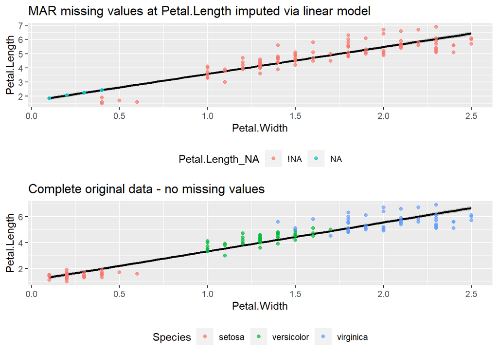

```r
vis_lm_imp <- ggplot(lm_imp_MAR, aes(x = Petal.Width, y = Petal.Length)) +
    geom_smooth(method = "lm", formula = y ~ x, color = "black", alpha = .5) +
  geom_point(aes(color = Petal.Length_NA), alpha =.7)+
  theme(legend.position = "bottom") +
  labs(title = "MAR missing values at Petal.Length imputed via linear model")

grid.arrange(vis_lm_imp, vis_complete) # Using grid.arrange() to compare plots, lets see the difference between a full data, and MCAR data
```

```r
model_MAR_lm_imp <- lm(Petal.Length ~ Petal.Width, lm_imp_MAR) # Establishing model




MAR_lm_imp <- tbl_regression(model_MAR_lm_imp) %>%
  modify_column_unhide(column = std.error) %>%
  add_glance_table(include = c(r.squared, adj.r.squared,
                               statistic, df.residual, p.value))

tbl_merge(tbls = list(Original_model, MAR, MAR_del,
                      MAR_mean_imp, MAR_lm_imp),
          tab_spanner = c("Original", "MAR", "MAR missing deleted",
                          "MAR mean imputation", "MAR linear model imputation"))
```

| **Characteristic** | Original **Beta** | Original **SE**<sup>1</sup> | Original **95% CI**<sup>1</sup> | Original **p-value** | MAR **Beta** | MAR **SE**<sup>1</sup> | MAR **95% CI**<sup>1</sup> | MAR **p-value** | MAR missing deleted **Beta** | MAR missing deleted **SE**<sup>1</sup> | MAR missing deleted **95% CI**<sup>1</sup> | MAR missing deleted **p-value** | MAR mean imputation **Beta** | MAR mean imputation **SE**<sup>1</sup> | MAR mean imputation **95% CI**<sup>1</sup> | MAR mean imputation **p-value** | MAR linear model imputation **Beta** | MAR linear model imputation **SE**<sup>1</sup> | MAR linear model imputation **95% CI**<sup>1</sup> | MAR linear model imputation **p-value** |
| --- | --- | --- | --- | --- | --- | --- | --- | --- | --- | --- | --- | --- | --- | --- | --- | --- | --- | --- | --- | --- |
| Petal.Width | 2.2 | 0.051 | 2.1, 2.3 | <0.001 | 1.9 | 0.104 | 1.7, 2.1 | <0.001 | 1.9 | 0.104 | 1.7, 2.1 | <0.001 | 0.55 | 0.085 | 0.38, 0.71 | <0.001 | 1.9 | 0.047 | 1.8, 2.0 | <0.001 |
| R² | 0.927 |  |  |  | 0.764 |  |  |  | 0.764 |  |  |  | 0.220 |  |  |  | 0.918 |  |  |  |
| Adjusted R² | 0.927 |  |  |  | 0.762 |  |  |  | 0.762 |  |  |  | 0.215 |  |  |  | 0.918 |  |  |  |
| Statistic | 1,882 |  |  |  | 334 |  |  |  | 334 |  |  |  | 41.8 |  |  |  | 1,667 |  |  |  |
| Residual df | 148 |  |  |  | 103 |  |  |  | 103 |  |  |  | 148 |  |  |  | 148 |  |  |  |
| p-value | <0.001 |  |  |  | <0.001 |  |  |  | <0.001 |  |  |  | <0.001 |  |  |  | <0.001 |  |  |  |

<sup>1</sup> SE = Standard Error, CI = Confidence Interval

We see that the issue here is the linear model imputation method works well for us here in MAR - But we are still risking overfitting.

Again we will use the predictive mean matching (pmm) within a multiple imputed chained equation setup to compare (remember, this is reccomended best practice).

### PMM - predicitive mean matching

```r
pmm_MAR <- mice(MAR_iris, method = "pmm", m =5, maxit = 5, seed = 123, print = FALSE)
pmm_MAR_complete <- complete(pmm_MAR, 5) # Please note this is a simplified approach, and that best practice requires pool and testing against a model. However, as a demonstration it is still effective.
```

```r
MAR_pmm_imp_summary <- pmm_MAR_complete %>%
  dplyr::select(`Sepal.Length`, `Sepal.Width`, `Petal.Length`, `Petal.Width`, `Species`) %>% # selecting to avoid summaries of shadow variables.
  tbl_summary( statistic = list(
      all_continuous() ~ "{mean} ({sd})",
      all_categorical() ~ "{n} / {N} ({p}%)"
    ))

tbl_merge(tbls = list(original_summary, MAR_summary, MAR_del_summary, MAR_mean_imp_summary, MAR_lm_imp_summary, MAR_pmm_imp_summary),
          tab_spanner = c("Original", "MAR", "MAR deleted missing", "MAR mean imputed", "MAR linear model imp", "MAR pmm imputed")) # using to compare summaries of original and missing data.
```

| **Characteristic** | Original **N = 150**<sup>1</sup> | MAR **N = 150**<sup>1</sup> | MAR deleted missing **N = 105**<sup>1</sup> | MAR mean imputed **N = 150**<sup>1</sup> | MAR linear model imp **N = 150**<sup>1</sup> | MAR pmm imputed **N = 150**<sup>1</sup> |
| --- | --- | --- | --- | --- | --- | --- |
| Sepal.Length | 5.84 (0.83) | 5.84 (0.83) | 6.21 (0.69) | 5.84 (0.83) | 5.84 (0.83) | 5.84 (0.83) |
| Sepal.Width | 3.06 (0.44) | 3.06 (0.44) | 2.90 (0.35) | 3.06 (0.44) | 3.06 (0.44) | 3.06 (0.44) |
| Petal.Length | 3.76 (1.77) | 4.75 (1.06) | 4.75 (1.06) | 4.75 (0.89) | 3.96 (1.51) | 3.83 (1.67) |
| Unknown |  | 45 |  |  |  |  |
| Petal.Width | 1.20 (0.76) | 1.20 (0.76) | 1.62 (0.49) | 1.20 (0.76) | 1.20 (0.76) | 1.20 (0.76) |
| Species |  |  |  |  |  |  |
| setosa | 50 / 150 (33%) | 50 / 150 (33%) | 5 / 105 (4.8%) | 50 / 150 (33%) | 50 / 150 (33%) | 50 / 150 (33%) |
| versicolor | 50 / 150 (33%) | 50 / 150 (33%) | 50 / 105 (48%) | 50 / 150 (33%) | 50 / 150 (33%) | 50 / 150 (33%) |
| virginica | 50 / 150 (33%) | 50 / 150 (33%) | 50 / 105 (48%) | 50 / 150 (33%) | 50 / 150 (33%) | 50 / 150 (33%) |

<sup>1</sup> Mean (SD); n / N (%)

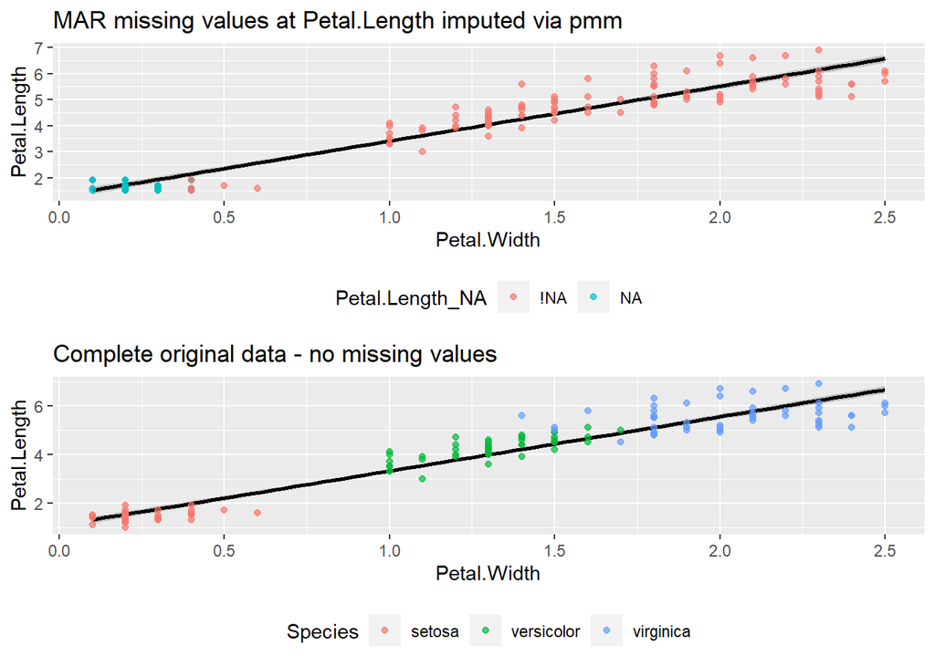

```r
vis_pmm_imp <- ggplot(pmm_MAR_complete, aes(x = Petal.Width, y = Petal.Length)) +
    geom_smooth(method = "lm", formula = y ~ x, color = "black", alpha = .5) +
  geom_point(aes(color = Petal.Length_NA), alpha =.7)+
  theme(legend.position = "bottom") +
  labs(title = "MAR missing values at Petal.Length imputed via pmm")

grid.arrange(vis_pmm_imp, vis_complete) # Using grid.arrange() to compare plots, lets see the difference between a full data, and MCAR data
```

```r
model_MAR_pmm_imp <- lm(Petal.Length ~ Petal.Width, pmm_MAR_complete) # Establishing model




MAR_pmm_imp <- tbl_regression(model_MAR_pmm_imp) %>%
  modify_column_unhide(column = std.error) %>%
  add_glance_table(include = c(r.squared, adj.r.squared,
                               statistic, df.residual, p.value))

tbl_merge(tbls = list(Original_model, MAR, MAR_del, MAR_mean_imp, MAR_lm_imp, MAR_pmm_imp),
          tab_spanner = c("Original", "MAR", "MAR missing deleted", "MAR mean imputation", "MAR linear model imputation", "MAR predictive mean matching imputation"))
```

| **Characteristic** | Original **Beta** | Original **SE**<sup>1</sup> | Original **95% CI**<sup>1</sup> | Original **p-value** | MAR **Beta** | MAR **SE**<sup>1</sup> | MAR **95% CI**<sup>1</sup> | MAR **p-value** | MAR missing deleted **Beta** | MAR missing deleted **SE**<sup>1</sup> | MAR missing deleted **95% CI**<sup>1</sup> | MAR missing deleted **p-value** | MAR mean imputation **Beta** | MAR mean imputation **SE**<sup>1</sup> | MAR mean imputation **95% CI**<sup>1</sup> | MAR mean imputation **p-value** | MAR linear model imputation **Beta** | MAR linear model imputation **SE**<sup>1</sup> | MAR linear model imputation **95% CI**<sup>1</sup> | MAR linear model imputation **p-value** | MAR predictive mean matching imputation **Beta** | MAR predictive mean matching imputation **SE**<sup>1</sup> | MAR predictive mean matching imputation **95% CI**<sup>1</sup> | MAR predictive mean matching imputation **p-value** |
| --- | --- | --- | --- | --- | --- | --- | --- | --- | --- | --- | --- | --- | --- | --- | --- | --- | --- | --- | --- | --- | --- | --- | --- | --- |
| Petal.Width | 2.2 | 0.051 | 2.1, 2.3 | <0.001 | 1.9 | 0.104 | 1.7, 2.1 | <0.001 | 1.9 | 0.104 | 1.7, 2.1 | <0.001 | 0.55 | 0.085 | 0.38, 0.71 | <0.001 | 1.9 | 0.047 | 1.8, 2.0 | <0.001 | 2.1 | 0.050 | 2.0, 2.2 | <0.001 |
| R² | 0.927 |  |  |  | 0.764 |  |  |  | 0.764 |  |  |  | 0.220 |  |  |  | 0.918 |  |  |  | 0.924 |  |  |  |
| Adjusted R² | 0.927 |  |  |  | 0.762 |  |  |  | 0.762 |  |  |  | 0.215 |  |  |  | 0.918 |  |  |  | 0.923 |  |  |  |
| Statistic | 1,882 |  |  |  | 334 |  |  |  | 334 |  |  |  | 41.8 |  |  |  | 1,667 |  |  |  | 1,794 |  |  |  |
| Residual df | 148 |  |  |  | 103 |  |  |  | 103 |  |  |  | 148 |  |  |  | 148 |  |  |  | 148 |  |  |  |
| p-value | <0.001 |  |  |  | <0.001 |  |  |  | <0.001 |  |  |  | <0.001 |  |  |  | <0.001 |  |  |  | <0.001 |  |  |  |

<sup>1</sup> SE = Standard Error, CI = Confidence Interval

So what do we see when comparing *PMM* to other methods? Well, it brings in an accurate prediction, but also with “noise” thrown in. As a result, the model does not over-fit in the way that *linear regression* imputation does. This certainly looks closer to the sweet spot.

Conclusion for best methods for *MAR* data - *PMM* will have the smallest biasing impact under MAR conditions.

## MNAR missing data

To simulate MNAR data in the IRIS dataset, we will need to remove the `Petal.Width` variable, due to it’s high covariance with `Petal.Length`. So lets imagine that the research in this case forgot to record data on `Petal.Width`, `Sepal.Width`, and `Species`… and then realised entries were missing. Let’s examine the effect this would have, and what they could do about it

```r
iris_id <- iris %>% mutate(ID = row_number()) # Creating ID number - this will be useful for later!
MNAR_iris <- iris_id %>% select(Petal.Length, Sepal.Length, ID) %>% # Choosing only Petal.Length + Sepal.Length - other variables "disapeered"
  delete_MNAR_censoring( cols_mis = "Petal.Length",  p =.3, where = "both") %>% bind_shadow()# here we have asked data to be missing in the `Petal.Length` variable, and for 30% of data to be missing in the MNAR condition.  Setting `where` to both, so missing data present at both sides.

MNAR_summary <- MNAR_iris %>%
  dplyr::select(`Sepal.Length`,  `Petal.Length`) %>% # selecting to avoid summaries of shadow variables.
  tbl_summary( statistic = list(
      all_continuous() ~ "{mean} ({sd})",
      all_categorical() ~ "{n} / {N} ({p}%)"
    ))

tbl_merge(tbls = list(original_summary, MCAR_summary, MAR_summary, MNAR_summary),
          tab_spanner = c("Original", "MCAR","MAR", "MNAR")) # using to compare summaries of original and missing data.
```

| **Characteristic** | Original **N = 150**<sup>1</sup> | MCAR **N = 150**<sup>1</sup> | MAR **N = 150**<sup>1</sup> | MNAR **N = 150**<sup>2</sup> |
| --- | --- | --- | --- | --- |
| Sepal.Length | 5.84 (0.83) | 5.84 (0.83) | 5.84 (0.83) | 5.84 (0.83) |
| Sepal.Width | 3.06 (0.44) | 3.06 (0.44) | 3.06 (0.44) |  |
| Petal.Length | 3.76 (1.77) | 3.71 (1.80) | 4.75 (1.06) | 3.81 (1.42) |
| Unknown |  | 45 | 45 | 45 |
| Petal.Width | 1.20 (0.76) | 1.20 (0.76) | 1.20 (0.76) |  |
| Species |  |  |  |  |
| setosa | 50 / 150 (33%) | 50 / 150 (33%) | 50 / 150 (33%) |  |
| versicolor | 50 / 150 (33%) | 50 / 150 (33%) | 50 / 150 (33%) |  |
| virginica | 50 / 150 (33%) | 50 / 150 (33%) | 50 / 150 (33%) |  |

<sup>1</sup> Mean (SD); n / N (%)  
<sup>2</sup> Mean (SD)

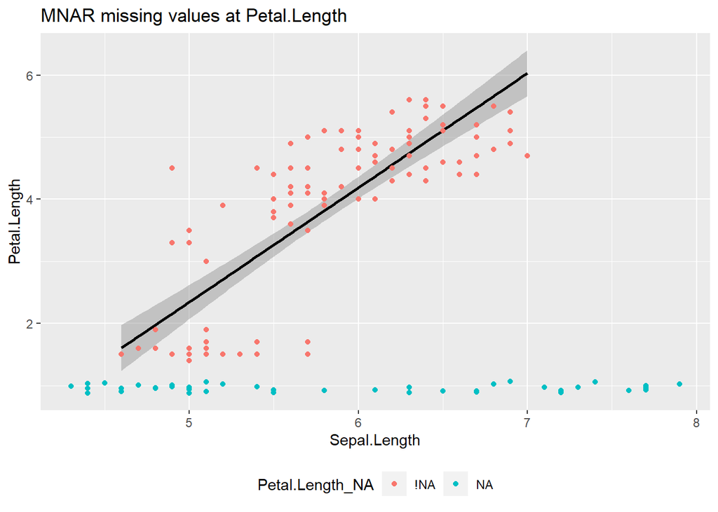

```r
vis_MNAR <- ggplot(MNAR_iris, aes(x = Sepal.Length, y = Petal.Length, color = Petal.Length_NA)) + # Using Sepal.Width  to examine here
    geom_smooth(method = "lm", formula = y ~ x, color = "black", alpha = .5) +
  geom_point(alpha = .7)+
  geom_miss_point() + # using grid_miss_point() from earlier to view difference
  theme(legend.position = "bottom") +
  labs(title = "MNAR missing values at Petal.Length")

# Re-setting comparison plots of MAR and MCAR to match data
vis_MAR <- ggplot(MAR_iris, aes(x = Sepal.Length, y = Petal.Length, color = Petal.Length_NA)) +
    geom_smooth(method = "lm", formula = y ~ x, color = "black", alpha = .5) +
  geom_point(alpha = .7)+
  geom_miss_point() +
  theme(legend.position = "bottom") +
  labs(title = "MAR missing values at Petal.Length")

vis_MCAR <- ggplot(MCAR_iris, aes(x = Sepal.Length, y = Petal.Length, color = Petal.Length_NA)) +
    geom_smooth(method = "lm", formula = y ~ x, color = "black", alpha = .5) +
  geom_point(alpha = .7)+
  geom_miss_point() + # using grid_miss_point() from earlier to view difference
  theme(legend.position = "bottom") +
  labs(title = "MCAR missing values at Petal.Length")

vis_complete <- ggplot(iris, aes(x = Sepal.Length, y = Petal.Length)) +
    geom_smooth(method = "lm", color = "black", alpha = .5) +
  geom_point(aes(color = Species), alpha = .7)+
  theme(legend.position = "bottom") +
  labs(title = "Complete original data - no missing values") # Plot for comparison with original data.

vis_MNAR
```

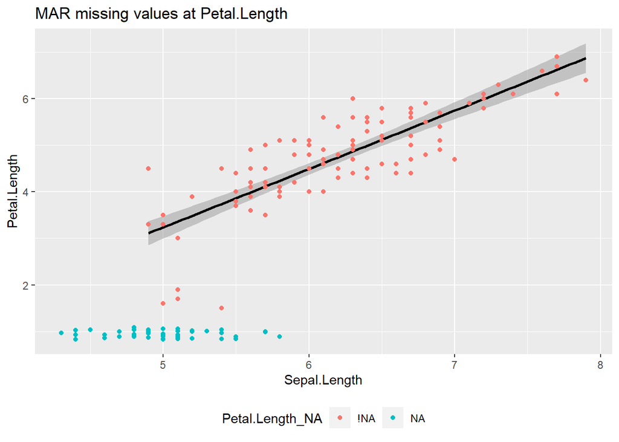

```r
vis_MAR
```

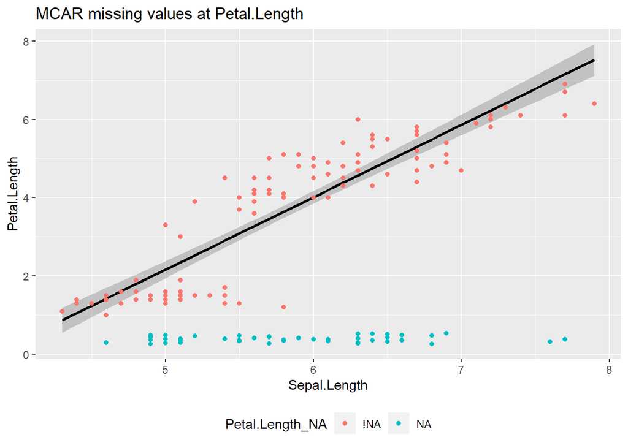

```r
vis_MCAR
```

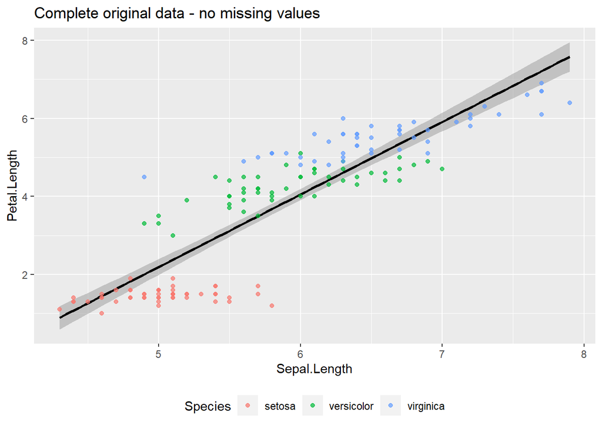

```r
vis_complete
```

```r
model_complete <- lm(Petal.Length ~ Sepal.Length, iris)# New original to compare more accurately

Original_model <- tbl_regression(model_complete) %>%
  modify_column_unhide(column = std.error) %>%
  add_glance_table(include = c(r.squared, adj.r.squared,
                               statistic, df.residual, p.value))

model_MNAR <- lm(Petal.Length ~ Sepal.Length, MNAR_iris) # Establishing model

# This next bit of code uses the gtsummary functions. It's very cool in creating quick tables, and definetly worth exploring in your own time. But for today their purpose is to allow us to quickly compare regression outputs



MNAR <- tbl_regression(model_MNAR) %>%
  modify_column_unhide(column = std.error) %>%
  add_glance_table(include = c(r.squared, adj.r.squared,
                               statistic, df.residual, p.value))

tbl_merge(tbls = list(Original_model, MCAR, MAR, MNAR),
          tab_spanner = c("Original", "MCAR" ,"MAR", "MNAR"))
```

| **Characteristic** | Original **Beta** | Original **SE**<sup>1</sup> | Original **95% CI**<sup>1</sup> | Original **p-value** | MCAR **Beta** | MCAR **SE**<sup>1</sup> | MCAR **95% CI**<sup>1</sup> | MCAR **p-value** | MAR **Beta** | MAR **SE**<sup>1</sup> | MAR **95% CI**<sup>1</sup> | MAR **p-value** | MNAR **Beta** | MNAR **SE**<sup>1</sup> | MNAR **95% CI**<sup>1</sup> | MNAR **p-value** |
| --- | --- | --- | --- | --- | --- | --- | --- | --- | --- | --- | --- | --- | --- | --- | --- | --- |
| Sepal.Length | 1.9 | 0.086 | 1.7, 2.0 | <0.001 |  |  |  |  |  |  |  |  | 1.8 | 0.138 | 1.6, 2.1 | <0.001 |
| R² | 0.760 |  |  |  | 0.929 |  |  |  | 0.764 |  |  |  | 0.633 |  |  |  |
| Adjusted R² | 0.758 |  |  |  | 0.928 |  |  |  | 0.762 |  |  |  | 0.629 |  |  |  |
| Statistic | 469 |  |  |  | 1,346 |  |  |  | 334 |  |  |  | 177 |  |  |  |
| Residual df | 148 |  |  |  | 103 |  |  |  | 103 |  |  |  | 103 |  |  |  |
| p-value | <0.001 |  |  |  | <0.001 |  |  |  | <0.001 |  |  |  | <0.001 |  |  |  |
| Petal.Width |  |  |  |  | 2.2 | 0.060 | 2.1, 2.3 | <0.001 | 1.9 | 0.104 | 1.7, 2.1 | <0.001 |  |  |  |  |

<sup>1</sup> SE = Standard Error, CI = Confidence Interval

We can see that the presence of MNAR data has impact the analysis. The mean value of Petal.Length has increased, and the model predictive power has decreased.

### Deletion

```r
# Here we use the na.omit() function to remove our missing data
delete_MNAR <- MNAR_iris %>% na.omit()

MNAR_del_summary <- delete_MNAR %>%
  dplyr::select(`Sepal.Length`,  `Petal.Length`) %>% # selecting to avoid summaries of shadow variables.
  tbl_summary( statistic = list(
      all_continuous() ~ "{mean} ({sd})",
      all_categorical() ~ "{n} / {N} ({p}%)"
    ))

tbl_merge(tbls = list(original_summary, MNAR_summary, MNAR_del_summary),
          tab_spanner = c("Original", "MNAR", "MNAR deleted missing")) # using to compare summaries of original and missing data.
```

| **Characteristic** | Original **N = 150**<sup>1</sup> | MNAR **N = 150**<sup>2</sup> | MNAR deleted missing **N = 105**<sup>2</sup> |
| --- | --- | --- | --- |
| Sepal.Length | 5.84 (0.83) | 5.84 (0.83) | 5.80 (0.61) |
| Sepal.Width | 3.06 (0.44) |  |  |
| Petal.Length | 3.76 (1.77) | 3.81 (1.42) | 3.81 (1.42) |
| Unknown |  | 45 |  |
| Petal.Width | 1.20 (0.76) |  |  |
| Species |  |  |  |
| setosa | 50 / 150 (33%) |  |  |
| versicolor | 50 / 150 (33%) |  |  |
| virginica | 50 / 150 (33%) |  |  |

<sup>1</sup> Mean (SD); n / N (%)  
<sup>2</sup> Mean (SD)

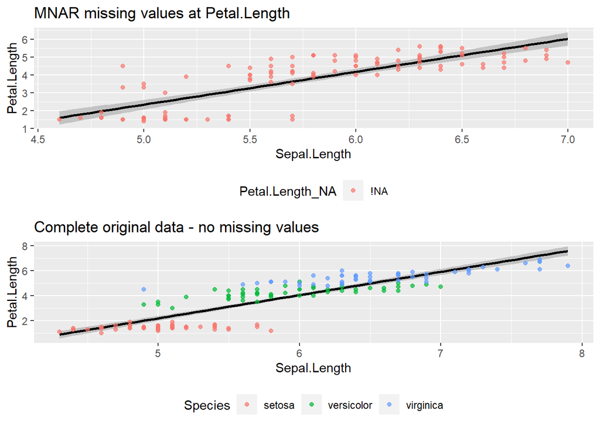

```r
vis_MNAR_delete <- ggplot(delete_MNAR, aes(x = Sepal.Length, y = Petal.Length)) +
    geom_smooth(method = "lm", formula = y ~ x, color = "black", alpha = .5) +
  geom_point(aes(color = Petal.Length_NA), alpha =.7)+
  theme(legend.position = "bottom") +
  labs(title = "MNAR missing values at Petal.Length")

grid.arrange(vis_MNAR_delete, vis_complete) # Using grid.arrange() to compare plots, lets see the difference between a full data, and MCAR data
```

```r
model_MNAR_del <- lm(Petal.Length ~ Sepal.Length, delete_MNAR) # Establishing model


MNAR_del <- tbl_regression(model_MNAR_del) %>%
  modify_column_unhide(column = std.error) %>%
  add_glance_table(include = c(r.squared, adj.r.squared,
                               statistic, df.residual, p.value))

tbl_merge(tbls = list(Original_model, MNAR, MNAR_del),
          tab_spanner = c("Original", "MNAR", "MNAR missing deleted"))
```

| **Characteristic** | Original **Beta** | Original **SE**<sup>1</sup> | Original **95% CI**<sup>1</sup> | Original **p-value** | MNAR **Beta** | MNAR **SE**<sup>1</sup> | MNAR **95% CI**<sup>1</sup> | MNAR **p-value** | MNAR missing deleted **Beta** | MNAR missing deleted **SE**<sup>1</sup> | MNAR missing deleted **95% CI**<sup>1</sup> | MNAR missing deleted **p-value** |
| --- | --- | --- | --- | --- | --- | --- | --- | --- | --- | --- | --- | --- |
| Sepal.Length | 1.9 | 0.086 | 1.7, 2.0 | <0.001 | 1.8 | 0.138 | 1.6, 2.1 | <0.001 | 1.8 | 0.138 | 1.6, 2.1 | <0.001 |
| R² | 0.760 |  |  |  | 0.633 |  |  |  | 0.633 |  |  |  |
| Adjusted R² | 0.758 |  |  |  | 0.629 |  |  |  | 0.629 |  |  |  |
| Statistic | 469 |  |  |  | 177 |  |  |  | 177 |  |  |  |
| Residual df | 148 |  |  |  | 103 |  |  |  | 103 |  |  |  |
| p-value | <0.001 |  |  |  | <0.001 |  |  |  | <0.001 |  |  |  |

<sup>1</sup> SE = Standard Error, CI = Confidence Interval

Deleting every missing value provides similar results to ignoring every missing value - but notice how deleting missing variables from Petal.Length has again impacted the means in other variables. This can be exaggerated if data is missing across multiple variables.

### Mean imputation.

```r
# Here we use the impute_mean() function to impute the mean values to our Petal.Length variable.

mean_imp_MNAR <- MNAR_iris %>% impute_mean()

MNAR_mean_imp_summary <- mean_imp_MNAR %>%
  dplyr::select(`Sepal.Length`,  `Petal.Length`) %>% # selecting to avoid summaries of shadow variables.
  tbl_summary( statistic = list(
      all_continuous() ~ "{mean} ({sd})",
      all_categorical() ~ "{n} / {N} ({p}%)"
    ))

tbl_merge(tbls = list(original_summary, MNAR_summary, MNAR_del_summary, MNAR_mean_imp_summary),
          tab_spanner = c("Original", "MNAR", "MNAR deleted missing", "MNAR mean imputed")) # using to compare summaries of original and missing data.
```

| **Characteristic** | Original **N = 150**<sup>1</sup> | MNAR **N = 150**<sup>2</sup> | MNAR deleted missing **N = 105**<sup>2</sup> | MNAR mean imputed **N = 150**<sup>2</sup> |
| --- | --- | --- | --- | --- |
| Sepal.Length | 5.84 (0.83) | 5.84 (0.83) | 5.80 (0.61) | 5.84 (0.83) |
| Sepal.Width | 3.06 (0.44) |  |  |  |
| Petal.Length | 3.76 (1.77) | 3.81 (1.42) | 3.81 (1.42) | 3.81 (1.18) |
| Unknown |  | 45 |  |  |
| Petal.Width | 1.20 (0.76) |  |  |  |
| Species |  |  |  |  |
| setosa | 50 / 150 (33%) |  |  |  |
| versicolor | 50 / 150 (33%) |  |  |  |
| virginica | 50 / 150 (33%) |  |  |  |

<sup>1</sup> Mean (SD); n / N (%)  
<sup>2</sup> Mean (SD)

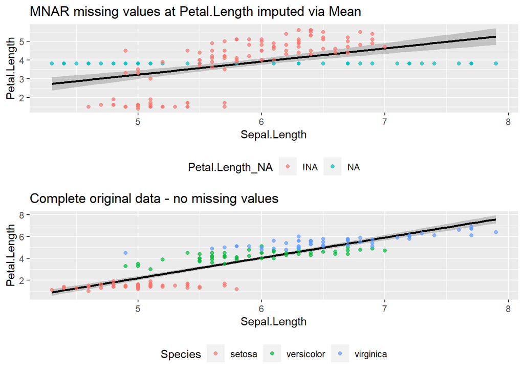

```r
vis_mean_imp <- ggplot(mean_imp_MNAR, aes(x = Sepal.Length, y = Petal.Length)) +
  geom_smooth(method = "lm", formula = y ~ x, color = "black", alpha = .5) +
  geom_point(aes(color = Petal.Length_NA), alpha =.7)+
  theme(legend.position = "bottom") +
  labs(title = "MNAR missing values at Petal.Length imputed via Mean")

grid.arrange(vis_mean_imp, vis_complete) # Using grid.arrange() to compare plots, lets see the difference between a full data, and MCAR data
```

```r
model_MNAR_imp <- lm(Petal.Length ~ Sepal.Length, mean_imp_MNAR) # Establishing model

MNAR_mean_imp <- tbl_regression(model_MNAR_imp) %>%
  modify_column_unhide(column = std.error) %>%
  add_glance_table(include = c(r.squared, adj.r.squared,
                               statistic, df.residual, p.value))

tbl_merge(tbls = list(Original_model, MNAR, MNAR_del, MNAR_mean_imp),
          tab_spanner = c("Original", "MNAR", "MNAR missing deleted", "MNAR mean imputation"))
```

| **Characteristic** | Original **Beta** | Original **SE**<sup>1</sup> | Original **95% CI**<sup>1</sup> | Original **p-value** | MNAR **Beta** | MNAR **SE**<sup>1</sup> | MNAR **95% CI**<sup>1</sup> | MNAR **p-value** | MNAR missing deleted **Beta** | MNAR missing deleted **SE**<sup>1</sup> | MNAR missing deleted **95% CI**<sup>1</sup> | MNAR missing deleted **p-value** | MNAR mean imputation **Beta** | MNAR mean imputation **SE**<sup>1</sup> | MNAR mean imputation **95% CI**<sup>1</sup> | MNAR mean imputation **p-value** |
| --- | --- | --- | --- | --- | --- | --- | --- | --- | --- | --- | --- | --- | --- | --- | --- | --- |
| Sepal.Length | 1.9 | 0.086 | 1.7, 2.0 | <0.001 | 1.8 | 0.138 | 1.6, 2.1 | <0.001 | 1.8 | 0.138 | 1.6, 2.1 | <0.001 | 0.70 | 0.102 | 0.50, 0.90 | <0.001 |
| R² | 0.760 |  |  |  | 0.633 |  |  |  | 0.633 |  |  |  | 0.241 |  |  |  |
| Adjusted R² | 0.758 |  |  |  | 0.629 |  |  |  | 0.629 |  |  |  | 0.236 |  |  |  |
| Statistic | 469 |  |  |  | 177 |  |  |  | 177 |  |  |  | 46.9 |  |  |  |
| Residual df | 148 |  |  |  | 103 |  |  |  | 103 |  |  |  | 148 |  |  |  |
| p-value | <0.001 |  |  |  | <0.001 |  |  |  | <0.001 |  |  |  | <0.001 |  |  |  |

<sup>1</sup> SE = Standard Error, CI = Confidence Interval

### Linear regression imputation.

```r
# Here we use the impute_lm() function to impute via regression
lm_imp_MNAR <- MNAR_iris %>% impute_lm(Petal.Length ~ Sepal.Length)

MNAR_lm_imp_summary <- lm_imp_MNAR %>%
  dplyr::select(`Sepal.Length`,  `Petal.Length`) %>% # selecting to avoid summaries of shadow variables.
  tbl_summary( statistic = list(
      all_continuous() ~ "{mean} ({sd})",
      all_categorical() ~ "{n} / {N} ({p}%)"
    ))

tbl_merge(tbls = list(original_summary, MNAR_summary, MNAR_del_summary, MNAR_mean_imp_summary, MNAR_lm_imp_summary),
          tab_spanner = c("Original", "MNAR", "MNAR deleted missing", "MNAR mean imputed", "MNAR linear model imp")) # using to compare summaries of original and missing data.
```

| **Characteristic** | Original **N = 150**<sup>1</sup> | MNAR **N = 150**<sup>2</sup> | MNAR deleted missing **N = 105**<sup>2</sup> | MNAR mean imputed **N = 150**<sup>2</sup> | MNAR linear model imp **N = 150**<sup>2</sup> |
| --- | --- | --- | --- | --- | --- |
| Sepal.Length | 5.84 (0.83) | 5.84 (0.83) | 5.80 (0.61) | 5.84 (0.83) | 5.84 (0.83) |
| Sepal.Width | 3.06 (0.44) |  |  |  |  |
| Petal.Length | 3.76 (1.77) | 3.81 (1.42) | 3.81 (1.42) | 3.81 (1.18) | 3.90 (1.69) |
| Unknown |  | 45 |  |  |  |
| Petal.Width | 1.20 (0.76) |  |  |  |  |
| Species |  |  |  |  |  |
| setosa | 50 / 150 (33%) |  |  |  |  |
| versicolor | 50 / 150 (33%) |  |  |  |  |
| virginica | 50 / 150 (33%) |  |  |  |  |

<sup>1</sup> Mean (SD); n / N (%)  
<sup>2</sup> Mean (SD)

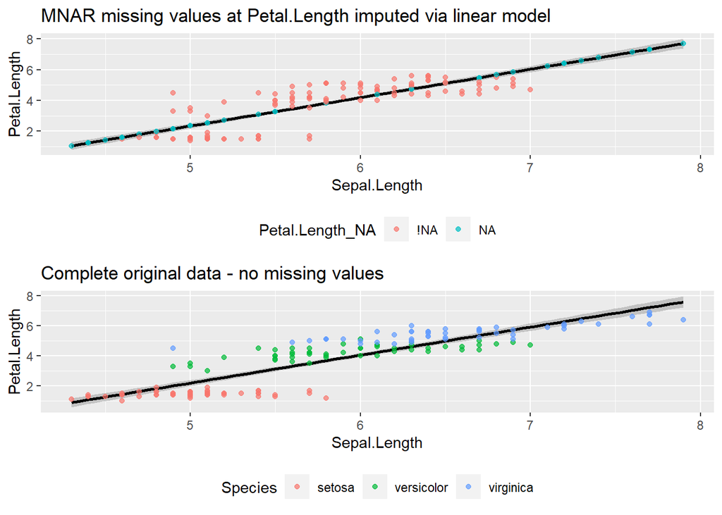

```r
vis_lm_imp <- ggplot(lm_imp_MNAR, aes(x = Sepal.Length, y = Petal.Length)) +
  geom_smooth(method = "lm", formula = y ~ x, color = "black", alpha = .5) +
  geom_point(aes(color = Petal.Length_NA), alpha =.7)+
  theme(legend.position = "bottom") +
  labs(title = "MNAR missing values at Petal.Length imputed via linear model")

grid.arrange(vis_lm_imp, vis_complete) # Using grid.arrange() to compare plots, lets see the difference between a full data, and MCAR data
```

```r
model_MNAR_lm_imp <- lm(Petal.Length ~ Sepal.Length, lm_imp_MNAR) # Establishing model




MNAR_lm_imp <- tbl_regression(model_MNAR_lm_imp) %>%
  modify_column_unhide(column = std.error) %>%
  add_glance_table(include = c(r.squared, adj.r.squared,
                               statistic, df.residual, p.value))

tbl_merge(tbls = list(Original_model, MNAR, MNAR_del, MNAR_mean_imp, MNAR_lm_imp),
          tab_spanner = c("Original", "MNAR", "MNAR missing deleted", "MNAR mean imputation", "MNAR linear model imputation"))
```

| **Characteristic** | Original **Beta** | Original **SE**<sup>1</sup> | Original **95% CI**<sup>1</sup> | Original **p-value** | MNAR **Beta** | MNAR **SE**<sup>1</sup> | MNAR **95% CI**<sup>1</sup> | MNAR **p-value** | MNAR missing deleted **Beta** | MNAR missing deleted **SE**<sup>1</sup> | MNAR missing deleted **95% CI**<sup>1</sup> | MNAR missing deleted **p-value** | MNAR mean imputation **Beta** | MNAR mean imputation **SE**<sup>1</sup> | MNAR mean imputation **95% CI**<sup>1</sup> | MNAR mean imputation **p-value** | MNAR linear model imputation **Beta** | MNAR linear model imputation **SE**<sup>1</sup> | MNAR linear model imputation **95% CI**<sup>1</sup> | MNAR linear model imputation **p-value** |
| --- | --- | --- | --- | --- | --- | --- | --- | --- | --- | --- | --- | --- | --- | --- | --- | --- | --- | --- | --- | --- |
| Sepal.Length | 1.9 | 0.086 | 1.7, 2.0 | <0.001 | 1.8 | 0.138 | 1.6, 2.1 | <0.001 | 1.8 | 0.138 | 1.6, 2.1 | <0.001 | 0.70 | 0.102 | 0.50, 0.90 | <0.001 | 1.8 | 0.071 | 1.7, 2.0 | <0.001 |
| R² | 0.760 |  |  |  | 0.633 |  |  |  | 0.633 |  |  |  | 0.241 |  |  |  | 0.819 |  |  |  |
| Adjusted R² | 0.758 |  |  |  | 0.629 |  |  |  | 0.629 |  |  |  | 0.236 |  |  |  | 0.818 |  |  |  |
| Statistic | 469 |  |  |  | 177 |  |  |  | 177 |  |  |  | 46.9 |  |  |  | 670 |  |  |  |
| Residual df | 148 |  |  |  | 103 |  |  |  | 103 |  |  |  | 148 |  |  |  | 148 |  |  |  |
| p-value | <0.001 |  |  |  | <0.001 |  |  |  | <0.001 |  |  |  | <0.001 |  |  |  | <0.001 |  |  |  |

<sup>1</sup> SE = Standard Error, CI = Confidence Interval